# Movie recommendation system

Recommender systems are one of the most successful and widespread application of machine learning technologies in business. You can find large scale recommender systems in retail, video on demand, or music streaming.

- *Examples of recommendation systems are:*
  1. Offering news articles to on-line newspaper readers, based on a prediction of reader interests.
  2. Offering customers of an on-line retailer suggestions about what they might like to buy, based on their past history of purchases and/or product searches.
  3. Recommending movies to user based on there previous watch

[figure not shown]

# Index

- Exploratory Data Analysis(EDA)
- Content based filtering
- Collaborative Filtering
  - Memory based collaborative filtering
    - User-Item Filtering
    - Item-Item Filtering
  - Model based collaborative filtering
    - Single Value Decomposition(SVD)
    - SVD++
- Evaluating Collaborative Filtering using SVD
- Hybrid Model

## Load Libraries

```python
from math import sqrt
import pandas as pd
import numpy as np
import seaborn as sns
from matplotlib import pyplot as plt
from sklearn.feature_extraction.text import TfidfVectorizer
from sklearn.metrics.pairwise import linear_kernel
```

# Dataset : Movielens

https://grouplens.org/datasets/movielens/100k

```python
# Reading ratings file
ratings = pd.read_csv('ratings.csv', sep=',', encoding='latin-1', usecols=['userId','movieId','rating','timestamp'])

# Reading movies file
movies = pd.read_csv('movies.csv', sep=',', encoding='latin-1', usecols=['movieId','title','genres'])
```

```python
df_movies = movies
df_ratings = ratings
```

## Exploratory Data Analysis(EDA)

```python
df_movies.head(5)
```

|  | movieId | title | genres |
| --- | --- | --- | --- |
| 0 | 1 | Toy Story (1995) | Adventure\|Animation\|Children\|Comedy\|Fantasy |
| 1 | 2 | Jumanji (1995) | Adventure\|Children\|Fantasy |
| 2 | 3 | Grumpier Old Men (1995) | Comedy\|Romance |
| 3 | 4 | Waiting to Exhale (1995) | Comedy\|Drama\|Romance |
| 4 | 5 | Father of the Bride Part II (1995) | Comedy |

### Most popular genres of movie released

```
<BarContainer object of 19 artists>
```

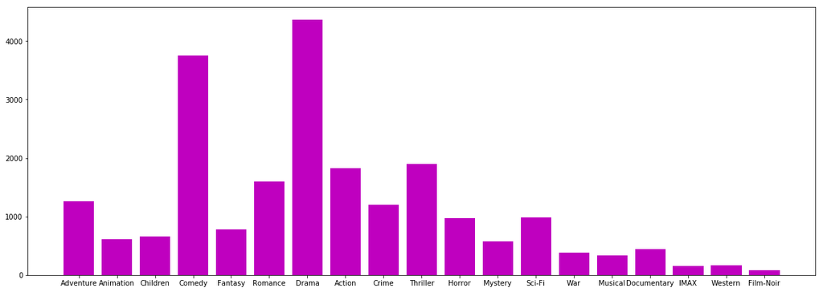

```python
plt.figure(figsize=(20,7))
generlist = df_movies['genres'].apply(lambda generlist_movie : str(generlist_movie).split("|"))
geners_count = {}

for generlist_movie in generlist:
    for gener in generlist_movie:
        if(geners_count.get(gener,False)):
            geners_count[gener]=geners_count[gener]+1
        else:
            geners_count[gener] = 1
geners_count.pop("(no genres listed)")
plt.bar(geners_count.keys(),geners_count.values(),color='m')
```

```python
df_ratings.head(5)
```

|  | userId | movieId | rating | timestamp |
| --- | --- | --- | --- | --- |
| 0 | 1 | 1 | 4.0 | 964982703 |
| 1 | 1 | 3 | 4.0 | 964981247 |
| 2 | 1 | 6 | 4.0 | 964982224 |
| 3 | 1 | 47 | 5.0 | 964983815 |
| 4 | 1 | 50 | 5.0 | 964982931 |

### Distribution of users rating

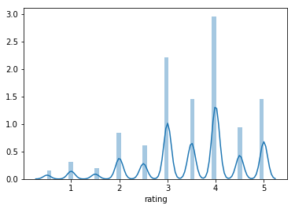

```python
sns.distplot(df_ratings["rating"]);
```

```python
print("Shape of frames: \n"+ " Rating DataFrame"+ str(df_ratings.shape)+"\n Movies DataFrame"+ str(df_movies.shape))
```

```
Shape of frames:
 Rating DataFrame(100836, 4)
 Movies DataFrame(9742, 3)
```

```python
merge_ratings_movies = pd.merge(df_movies, df_ratings, on='movieId', how='inner')
```

```python
merge_ratings_movies.head(2)
```

|  | movieId | title | genres | userId | rating | timestamp |
| --- | --- | --- | --- | --- | --- | --- |
| 0 | 1 | Toy Story (1995) | Adventure\|Animation\|Children\|Comedy\|Fantasy | 1 | 4.0 | 964982703 |
| 1 | 1 | Toy Story (1995) | Adventure\|Animation\|Children\|Comedy\|Fantasy | 5 | 4.0 | 847434962 |

```python
merge_ratings_movies = merge_ratings_movies.drop('timestamp', axis=1)
```

```python
merge_ratings_movies.shape
```

```
(100836, 5)
```

Grouping the rating based on user

```python
ratings_grouped_by_users = merge_ratings_movies.groupby('userId').agg([np.size, np.mean])
```

```python
ratings_grouped_by_users.head(2)
```

| userId | movieId size | movieId mean | rating size | rating mean |
| --- | --- | --- | --- | --- |
| 1 | 232 | 1854.603448 | 232.0 | 4.366379 |
| 2 | 29 | 70350.275862 | 29.0 | 3.948276 |

```python
ratings_grouped_by_users = ratings_grouped_by_users.drop('movieId', axis = 1)
```

### Top 10 users who have rated most of the movies

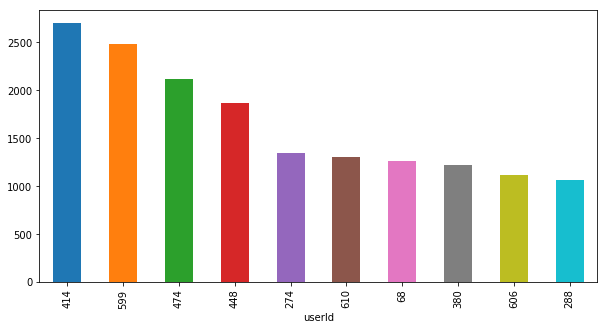

```python
ratings_grouped_by_users['rating']['size'].sort_values(ascending=False).head(10).plot('bar', figsize = (10,5))
```

```python
ratings_grouped_by_movies = merge_ratings_movies.groupby('movieId').agg([np.mean], np.size)
```

```python
ratings_grouped_by_movies.shape
```

```
(9724, 2)
```

```python
ratings_grouped_by_movies.head(3)
```

| movieId | userId mean | rating mean |
| --- | --- | --- |
| 1 | 306.530233 | 3.920930 |
| 2 | 329.554545 | 3.431818 |
| 3 | 283.596154 | 3.259615 |

```python
ratings_grouped_by_movies = ratings_grouped_by_movies.drop('userId', axis=1)
```

### Movies with high average rating

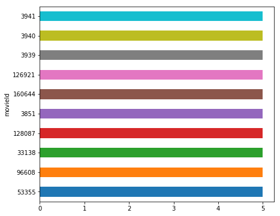

```python
ratings_grouped_by_movies['rating']['mean'].sort_values(ascending=False).head(10).plot(kind='barh', figsize=(7,6));
```

### Movies with low average rating

```python
low_rated_movies_filter = ratings_grouped_by_movies['rating']['mean']< 1.5
```

```python
low_rated_movies = ratings_grouped_by_movies[low_rated_movies_filter]
```

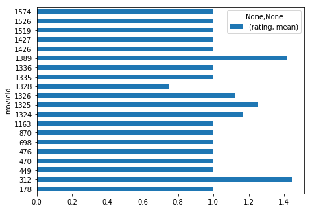

```python
low_rated_movies.head(20).plot(kind='barh', figsize=(7,5));
```

```python
low_rated_movies.head(10)
```

| movieId | rating mean |
| --- | --- |
| 178 | 1.000000 |
| 312 | 1.444444 |
| 449 | 1.000000 |
| 470 | 1.000000 |
| 476 | 1.000000 |
| 698 | 1.000000 |
| 870 | 1.000000 |
| 1163 | 1.000000 |
| 1324 | 1.166667 |
| 1325 | 1.250000 |

# Content based filtering

The concepts of Term Frequency (TF) and Inverse Document Frequency (IDF) are used in information retrieval systems and also content based filtering mechanisms (such as a content based recommender). They are used to determine the relative importance of a document / article / news item / movie etc.

### Term Frequency (TF) and Inverse Document Frequency (IDF)

TF is simply the frequency of a word in a document. IDF is the inverse of the document frequency among the whole corpus of documents. TF-IDF is used mainly because of two reasons: Suppose we search for “the rise of analytics” on Google. It is certain that “the” will occur more frequently than “analytics” but the relative importance of analytics is higher than the search query point of view. In such cases, TF-IDF weighting negates the effect of high frequency words in determining the importance of an item (document).

We will consider genres as an important parameter to recommend user the movie he watches based on generes of movie user has already watched.

[figure not shown]

For calculating distances, many similarity coefficients can be calculated. Most widely used similarity coefficients are Euclidean, Cosine, Pearson Correlation etc.

**Cosine similarity** is a measure of similarity between two non-zero vectors of an inner product space that measures the cosine of the angle between them. Given two vectors of attributes, A and B, the cosine similarity, cos(θ), is represented using a dot product and magnitude as Inline-style:

[figure not shown]

We will use cosine distance here. Here we are insterested in similarity. That means higher the value more similar they are. But as the function gives us the distance, we will deduct it from 1.

```python
# Define a TF-IDF Vectorizer Object.
tfidf_movies_genres = TfidfVectorizer(token_pattern = '[a-zA-Z0-9\-]+')

#Replace NaN with an empty string
df_movies['genres'] = df_movies['genres'].replace(to_replace="(no genres listed)", value="")

#Construct the required TF-IDF matrix by fitting and transforming the data
tfidf_movies_genres_matrix = tfidf_movies_genres.fit_transform(df_movies['genres'])
# print(tfidf_movies_genres.get_feature_names())
# Compute the cosine similarity matrix
# print(tfidf_movies_genres_matrix.shape)
# print(tfidf_movies_genres_matrix.dtype)
cosine_sim_movies = linear_kernel(tfidf_movies_genres_matrix, tfidf_movies_genres_matrix)
# print(cosine_sim_movies)
```

```python
def get_recommendations_based_on_genres(movie_title, cosine_sim_movies=cosine_sim_movies):
    """
    Calculates top 2 movies to recommend based on given movie titles genres.
    :param movie_title: title of movie to be taken for base of recommendation
    :param cosine_sim_movies: cosine similarity between movies
    :return: Titles of movies recommended to user
    """
    # Get the index of the movie that matches the title
    idx_movie = df_movies.loc[df_movies['title'].isin([movie_title])]
    idx_movie = idx_movie.index

    # Get the pairwsie similarity scores of all movies with that movie
    sim_scores_movies = list(enumerate(cosine_sim_movies[idx_movie][0]))

    # Sort the movies based on the similarity scores
    sim_scores_movies = sorted(sim_scores_movies, key=lambda x: x[1], reverse=True)

    # Get the scores of the 10 most similar movies
    sim_scores_movies = sim_scores_movies[1:3]

    # Get the movie indices
    movie_indices = [i[0] for i in sim_scores_movies]

    # Return the top 2 most similar movies
    return df_movies['title'].iloc[movie_indices]
```

```python
get_recommendations_based_on_genres("Father of the Bride Part II (1995)")
```

```
17                        Four Rooms (1995)
18    Ace Ventura: When Nature Calls (1995)
Name: title, dtype: object
```

```python
def get_recommendation_content_model(userId):
    """
    Calculates top movies to be recommended to user based on movie user has watched.
    :param userId: userid of user
    :return: Titles of movies recommended to user
    """
    recommended_movie_list = []
    movie_list = []
    df_rating_filtered = df_ratings[df_ratings["userId"]== userId]
    for key, row in df_rating_filtered.iterrows():
        movie_list.append((df_movies["title"][row["movieId"]==df_movies["movieId"]]).values)
    for index, movie in enumerate(movie_list):
        for key, movie_recommended in get_recommendations_based_on_genres(movie[0]).iteritems():
            recommended_movie_list.append(movie_recommended)

    # removing already watched movie from recommended list
    for movie_title in recommended_movie_list:
        if movie_title in movie_list:
            recommended_movie_list.remove(movie_title)

    return set(recommended_movie_list)
get_recommendation_content_model(1)
```

```
{'101 Dalmatians (One Hundred and One Dalmatians) (1961)',
 '39 Steps, The (1935)',
 'Ace Ventura: When Nature Calls (1995)',
 'Adventures in Babysitting (1987)',
 'Adventures of Robin Hood, The (1938)',
 'Alamo, The (1960)',
 'Alien Nation (1988)',
 'Amateur (1994)',
 'Amazing Panda Adventure, The (1995)',
 "Antonia's Line (Antonia) (1995)",
 'Antz (1998)',
 'Aristocats, The (1970)',
 'Around the World in 80 Days (1956)',
 'Assassins (1995)',
 'Austin Powers: The Spy Who Shagged Me (1999)',
 'BURN-E (2008)',
 'Babes in Toyland (1934)',
 'Backbeat (1993)',
 'Barb Wire (1996)',
 'Batman: Mystery of the Batwoman (2003)',
 'Beat the Devil (1953)',
 'Before the Rain (Pred dozhdot) (1994)',
 'Ben-Hur (1959)',
 'Big Bully (1996)',
 'Big Country, The (1958)',
 'Big Trouble in Little China (1986)',
 'Black Hole, The (1979)',
 'Blazing Saddles (1974)',
 'Blues Brothers 2000 (1998)',
 'Boot, Das (Boat, The) (1981)',
 'Bride of Frankenstein, The (Bride of Frankenstein) (1935)',
 'Broken Arrow (1996)',
 'Brothers Bloom, The (2008)',
 "Bug's Life, A (1998)",
 'Captain Blood (1935)',
 'Carpool (1996)',
 'Castle Freak (1995)',
 "Cats Don't Dance (1997)",
 'Catwoman (2004)',
 'Cemetery Man (Dellamorte Dellamore) (1994)',
```

[output cut: 149 more lines]

```
 'Transformers: The Movie (1986)',
 'True Grit (1969)',
 'Underneath (1995)',
 'Up (2009)',
 'Valiant (2005)',
 'Van Helsing (2004)',
 'Village of the Damned (1995)',
 'War of the Worlds, The (1953)',
 "We're Back! A Dinosaur's Story (1993)",
 'Were the World Mine (2008)',
 'What Dreams May Come (1998)',
 "What's Love Got to Do with It? (1993)",
 'Witches, The (1990)',
 'Wiz, The (1978)',
 'Wizards of Waverly Place: The Movie (2009)'}
```

# Model evaluation with KNN

Here the model is evaluated on based of if there is exact match of genres with the genres of movie which is already watch by user

```python
from sklearn.neighbors import KNeighborsClassifier
def get_movie_label(movie_id):
    """
    Get the cluster label to which movie belongs by KNN algorithm.
    :param movie_id: movie id
    :return: genres label to movie belong
    """
    classifier = KNeighborsClassifier(n_neighbors=5)
    x= tfidf_movies_genres_matrix
    y = df_movies.iloc[:,-1]
    classifier.fit(x, y)
    y_pred = classifier.predict(tfidf_movies_genres_matrix[movie_id])
    return y_pred
```

```python
true_count = 0
false_count = 0
def evaluate_content_based_model():
    """
    Evaluate content based model.
    """
    for key, colums in df_movies.iterrows():
        movies_recommended_by_model = get_recommendations_based_on_genres(colums["title"])
        predicted_genres  = get_movie_label(movies_recommended_by_model.index)
        for predicted_genre in predicted_genres:
            global true_count, false_count
            if predicted_genre == colums["genres"]:
                true_count = true_count+1
            else:
#                 print(colums["genres"])
#                 print(predicted_genre)
                false_count = false_count +1
evaluate_content_based_model()
total = true_count + false_count
print("Hit:"+ str(true_count/total))
print("Fault:" + str(false_count/total))
```

```
Hit:0.9325087251077807
Fault:0.06749127489221926
```

```python
from sklearn.metrics import pairwise_distances
from scipy.spatial.distance import cosine, correlation
```

```python
df_movies = movies
df_ratings = ratings
```

# Collaborative Filtering

Types of collaborative filtering techniques

- Memory based
  - User-Item Filtering
  - Item-Item Filtering
- Model based
  - Matrix Factorization
  - Clustering
  - Deep Learning

[figure not shown]

## Memory Based Approach

[figure not shown]

In either scenario, we builds a similarity matrix. For user-user collaborative filtering, the user-similarity matrix will consist of some distance metrics that measure the similarity between any two pairs of users. Likewise, the item-similarity matrix will measure the similarity between any two pairs of items.

There are 3 distance similarity metrics that are usually used in collaborative filtering:

- **Jaccard Similarity**
- **Cosine Similarity**
- **Pearson Similarity**

## Item-Item Filtering

Item-item collaborative filtering, or item-based, or item-to-item, is a form of collaborative filtering for recommender systems based on the similarity between items calculated using people's ratings of those items.

Item-item collaborative filtering was invented and used by Amazon.com

[figure not shown]

ITEM-ITEM collaborative filtering look for items that are similar to the articles that user has already rated and recommend most similar articles. But what does that mean when we say item-item similarity? In this case we don’t mean whether two items are the same by attribute like Fountain pen and pilot pen are similar because both are pen. Instead, what similarity means is how people treat two items the same in terms of like and dislike.

It is quite similar to previous algorithm, but instead of finding user’s look-alike, we try finding movie’s look-alike. Once we have movie’s look-alike matrix, we can easily recommend alike movies to user who have rated any movie from the dataset. This algorithm is far less resource consuming than user-user collaborative filtering. Hence, for a new user, the algorithm takes far lesser time than user-user collaborate as we don’t need all similarity scores between users. And with fixed number of movies, movie-movie look alike matrix is fixed over time.

## Implementation of Item-Item Filtering

```python
df_movies_ratings=pd.merge(df_movies, df_ratings)
```

```python
df_movies_ratings
```

|  | movieId | title | genres | userId | rating | timestamp |
| --- | --- | --- | --- | --- | --- | --- |
| 0 | 1 | Toy Story (1995) | Adventure\|Animation\|Children\|Comedy\|Fantasy | 1 | 4.0 | 964982703 |
| 1 | 1 | Toy Story (1995) | Adventure\|Animation\|Children\|Comedy\|Fantasy | 5 | 4.0 | 847434962 |
| 2 | 1 | Toy Story (1995) | Adventure\|Animation\|Children\|Comedy\|Fantasy | 7 | 4.5 | 1106635946 |
| 3 | 1 | Toy Story (1995) | Adventure\|Animation\|Children\|Comedy\|Fantasy | 15 | 2.5 | 1510577970 |
| 4 | 1 | Toy Story (1995) | Adventure\|Animation\|Children\|Comedy\|Fantasy | 17 | 4.5 | 1305696483 |
| 5 | 1 | Toy Story (1995) | Adventure\|Animation\|Children\|Comedy\|Fantasy | 18 | 3.5 | 1455209816 |
| 6 | 1 | Toy Story (1995) | Adventure\|Animation\|Children\|Comedy\|Fantasy | 19 | 4.0 | 965705637 |
| 7 | 1 | Toy Story (1995) | Adventure\|Animation\|Children\|Comedy\|Fantasy | 21 | 3.5 | 1407618878 |
| 8 | 1 | Toy Story (1995) | Adventure\|Animation\|Children\|Comedy\|Fantasy | 27 | 3.0 | 962685262 |
| 9 | 1 | Toy Story (1995) | Adventure\|Animation\|Children\|Comedy\|Fantasy | 31 | 5.0 | 850466616 |
| 10 | 1 | Toy Story (1995) | Adventure\|Animation\|Children\|Comedy\|Fantasy | 32 | 3.0 | 856736119 |
| 11 | 1 | Toy Story (1995) | Adventure\|Animation\|Children\|Comedy\|Fantasy | 33 | 3.0 | 939647444 |
| 12 | 1 | Toy Story (1995) | Adventure\|Animation\|Children\|Comedy\|Fantasy | 40 | 5.0 | 832058959 |
| 13 | 1 | Toy Story (1995) | Adventure\|Animation\|Children\|Comedy\|Fantasy | 43 | 5.0 | 848993983 |
| 14 | 1 | Toy Story (1995) | Adventure\|Animation\|Children\|Comedy\|Fantasy | 44 | 3.0 | 869251860 |
| 15 | 1 | Toy Story (1995) | Adventure\|Animation\|Children\|Comedy\|Fantasy | 45 | 4.0 | 951170182 |
| 16 | 1 | Toy Story (1995) | Adventure\|Animation\|Children\|Comedy\|Fantasy | 46 | 5.0 | 834787906 |
| 17 | 1 | Toy Story (1995) | Adventure\|Animation\|Children\|Comedy\|Fantasy | 50 | 3.0 | 1514238116 |
| 18 | 1 | Toy Story (1995) | Adventure\|Animation\|Children\|Comedy\|Fantasy | 54 | 3.0 | 830247330 |
| 19 | 1 | Toy Story (1995) | Adventure\|Animation\|Children\|Comedy\|Fantasy | 57 | 5.0 | 965796031 |
| 20 | 1 | Toy Story (1995) | Adventure\|Animation\|Children\|Comedy\|Fantasy | 63 | 5.0 | 1443199669 |
| 21 | 1 | Toy Story (1995) | Adventure\|Animation\|Children\|Comedy\|Fantasy | 64 | 4.0 | 1161520134 |
| 22 | 1 | Toy Story (1995) | Adventure\|Animation\|Children\|Comedy\|Fantasy | 66 | 4.0 | 1104643957 |
| 23 | 1 | Toy Story (1995) | Adventure\|Animation\|Children\|Comedy\|Fantasy | 68 | 2.5 | 1158531426 |
| 24 | 1 | Toy Story (1995) | Adventure\|Animation\|Children\|Comedy\|Fantasy | 71 | 5.0 | 864737933 |
| 25 | 1 | Toy Story (1995) | Adventure\|Animation\|Children\|Comedy\|Fantasy | 73 | 4.5 | 1464196374 |
| 26 | 1 | Toy Story (1995) | Adventure\|Animation\|Children\|Comedy\|Fantasy | 76 | 0.5 | 1439165548 |
| 27 | 1 | Toy Story (1995) | Adventure\|Animation\|Children\|Comedy\|Fantasy | 78 | 4.0 | 1252575124 |
| 28 | 1 | Toy Story (1995) | Adventure\|Animation\|Children\|Comedy\|Fantasy | 82 | 2.5 | 1084467729 |
| 29 | 1 | Toy Story (1995) | Adventure\|Animation\|Children\|Comedy\|Fantasy | 86 | 4.0 | 1344082549 |
| ... | ... | ... | ... | ... | ... | ... |
| 100806 | 188301 | Ant-Man and the Wasp (2018) | Action\|Adventure\|Comedy\|Fantasy\|Sci-Fi | 596 | 4.0 | 1535709468 |
| 100807 | 188675 | Dogman (2018) | Crime\|Drama | 318 | 3.5 | 1535035470 |
| 100808 | 188751 | Mamma Mia: Here We Go Again! (2018) | Comedy\|Romance | 212 | 4.5 | 1532362151 |
| 100809 | 188797 | Tag (2018) | Comedy | 514 | 4.0 | 1535941279 |
| 100810 | 188833 | The Man Who Killed Don Quixote (2018) | Adventure\|Comedy\|Fantasy | 318 | 4.5 | 1535035971 |
| 100811 | 189043 | Boundaries (2018) | Comedy\|Drama | 338 | 2.5 | 1530148447 |
| 100812 | 189111 | Spiral (2018) | Documentary | 338 | 3.0 | 1530148343 |
| 100813 | 189333 | Mission: Impossible - Fallout (2018) | Action\|Adventure\|Thriller | 184 | 4.0 | 1537110051 |
| 100814 | 189333 | Mission: Impossible - Fallout (2018) | Action\|Adventure\|Thriller | 248 | 3.5 | 1534602181 |
| 100815 | 189381 | SuperFly (2018) | Action\|Crime\|Thriller | 318 | 2.5 | 1536097988 |
| 100816 | 189547 | Iron Soldier (2010) | Action\|Sci-Fi | 210 | 1.0 | 1528486011 |
| 100817 | 189713 | BlacKkKlansman (2018) | Comedy\|Crime\|Drama | 462 | 2.5 | 1536467299 |
| 100818 | 190183 | The Darkest Minds (2018) | Sci-Fi\|Thriller | 50 | 3.5 | 1533302021 |
| 100819 | 190207 | Tilt (2011) | Drama\|Romance | 338 | 1.5 | 1530148481 |
| 100820 | 190209 | Jeff Ross Roasts the Border (2017) | Comedy | 338 | 4.0 | 1530148487 |
| 100821 | 190213 | John From (2015) | Drama | 338 | 1.0 | 1530148478 |
| 100822 | 190215 | Liquid Truth (2017) | Drama | 338 | 1.5 | 1530148477 |
| 100823 | 190219 | Bunny (1998) | Animation | 338 | 1.0 | 1530148473 |
| 100824 | 190221 | Hommage Ã Zgougou (et salut Ã Sabine Mamou) ... | Documentary | 338 | 1.0 | 1530148473 |
| 100825 | 191005 | Gintama (2017) | Action\|Adventure\|Comedy\|Sci-Fi | 184 | 4.5 | 1537109489 |
| 100826 | 193565 | Gintama: The Movie (2010) | Action\|Animation\|Comedy\|Sci-Fi | 184 | 3.5 | 1537098554 |
| 100827 | 193567 | anohana: The Flower We Saw That Day - The Movi... | Animation\|Drama | 184 | 3.0 | 1537099103 |
| 100828 | 193571 | Silver Spoon (2014) | Comedy\|Drama | 184 | 4.0 | 1537099392 |
| 100829 | 193573 | Love Live! The School Idol Movie (2015) | Animation | 184 | 4.0 | 1537099811 |
| 100830 | 193579 | Jon Stewart Has Left the Building (2015) | Documentary | 184 | 3.5 | 1537107259 |
| 100831 | 193581 | Black Butler: Book of the Atlantic (2017) | Action\|Animation\|Comedy\|Fantasy | 184 | 4.0 | 1537109082 |
| 100832 | 193583 | No Game No Life: Zero (2017) | Animation\|Comedy\|Fantasy | 184 | 3.5 | 1537109545 |
| 100833 | 193585 | Flint (2017) | Drama | 184 | 3.5 | 1537109805 |
| 100834 | 193587 | Bungo Stray Dogs: Dead Apple (2018) | Action\|Animation | 184 | 3.5 | 1537110021 |
| 100835 | 193609 | Andrew Dice Clay: Dice Rules (1991) | Comedy | 331 | 4.0 | 1537157606 |

100836 rows × 6 columns

Here Pivot table function is used as we want one to one maping between movies, user and their rating. So by default pivot_table command takes average if we have multiple values of one combination.

```python
ratings_matrix_items = df_movies_ratings.pivot_table(index=['movieId'],columns=['userId'],values='rating').reset_index(drop=True)
ratings_matrix_items.fillna( 0, inplace = True )
ratings_matrix_items.shape
```

```
(9724, 610)
```

```python
ratings_matrix_items
```

| userId | 1 | 2 | 3 | 4 | 5 | 6 | 7 | 8 | 9 | 10 | ... | 601 | 602 | 603 | 604 | 605 | 606 | 607 | 608 | 609 | 610 |
| --- | --- | --- | --- | --- | --- | --- | --- | --- | --- | --- | --- | --- | --- | --- | --- | --- | --- | --- | --- | --- | --- |
| 0 | 4.0 | 0.0 | 0.0 | 0.0 | 4.0 | 0.0 | 4.5 | 0.0 | 0.0 | 0.0 | ... | 4.0 | 0.0 | 4.0 | 3.0 | 4.0 | 2.5 | 4.0 | 2.5 | 3.0 | 5.0 |
| 1 | 0.0 | 0.0 | 0.0 | 0.0 | 0.0 | 4.0 | 0.0 | 4.0 | 0.0 | 0.0 | ... | 0.0 | 4.0 | 0.0 | 5.0 | 3.5 | 0.0 | 0.0 | 2.0 | 0.0 | 0.0 |
| 2 | 4.0 | 0.0 | 0.0 | 0.0 | 0.0 | 5.0 | 0.0 | 0.0 | 0.0 | 0.0 | ... | 0.0 | 0.0 | 0.0 | 0.0 | 0.0 | 0.0 | 0.0 | 2.0 | 0.0 | 0.0 |
| 3 | 0.0 | 0.0 | 0.0 | 0.0 | 0.0 | 3.0 | 0.0 | 0.0 | 0.0 | 0.0 | ... | 0.0 | 0.0 | 0.0 | 0.0 | 0.0 | 0.0 | 0.0 | 0.0 | 0.0 | 0.0 |
| 4 | 0.0 | 0.0 | 0.0 | 0.0 | 0.0 | 5.0 | 0.0 | 0.0 | 0.0 | 0.0 | ... | 0.0 | 0.0 | 0.0 | 3.0 | 0.0 | 0.0 | 0.0 | 0.0 | 0.0 | 0.0 |
| 5 | 4.0 | 0.0 | 0.0 | 0.0 | 0.0 | 4.0 | 0.0 | 0.0 | 0.0 | 0.0 | ... | 0.0 | 3.0 | 4.0 | 3.0 | 0.0 | 0.0 | 0.0 | 0.0 | 0.0 | 5.0 |
| 6 | 0.0 | 0.0 | 0.0 | 0.0 | 0.0 | 4.0 | 0.0 | 0.0 | 0.0 | 0.0 | ... | 0.0 | 0.0 | 0.0 | 0.0 | 0.0 | 2.5 | 0.0 | 0.0 | 0.0 | 0.0 |
| 7 | 0.0 | 0.0 | 0.0 | 0.0 | 0.0 | 3.0 | 0.0 | 0.0 | 0.0 | 0.0 | ... | 0.0 | 0.0 | 0.0 | 0.0 | 0.0 | 0.0 | 0.0 | 0.0 | 0.0 | 0.0 |
| 8 | 0.0 | 0.0 | 0.0 | 0.0 | 0.0 | 0.0 | 0.0 | 0.0 | 0.0 | 0.0 | ... | 0.0 | 0.0 | 0.0 | 0.0 | 0.0 | 0.0 | 0.0 | 0.0 | 0.0 | 0.0 |
| 9 | 0.0 | 0.0 | 0.0 | 0.0 | 0.0 | 3.0 | 0.0 | 2.0 | 0.0 | 0.0 | ... | 0.0 | 3.0 | 0.0 | 0.0 | 0.0 | 0.0 | 0.0 | 4.0 | 4.0 | 0.0 |
| 10 | 0.0 | 0.0 | 0.0 | 0.0 | 0.0 | 4.0 | 0.0 | 4.0 | 0.0 | 0.0 | ... | 0.0 | 3.0 | 0.0 | 0.0 | 0.0 | 2.5 | 3.0 | 0.0 | 0.0 | 0.0 |
| 11 | 0.0 | 0.0 | 0.0 | 0.0 | 0.0 | 0.0 | 0.0 | 0.0 | 0.0 | 0.0 | ... | 0.0 | 0.0 | 0.0 | 0.0 | 0.0 | 0.0 | 0.0 | 0.0 | 0.0 | 0.0 |
| 12 | 0.0 | 0.0 | 0.0 | 0.0 | 0.0 | 3.0 | 0.0 | 0.0 | 0.0 | 0.0 | ... | 0.0 | 0.0 | 0.0 | 0.0 | 0.0 | 0.0 | 0.0 | 0.0 | 0.0 | 0.0 |
| 13 | 0.0 | 0.0 | 0.0 | 0.0 | 0.0 | 0.0 | 0.0 | 0.0 | 0.0 | 0.0 | ... | 0.0 | 5.0 | 0.0 | 4.0 | 0.0 | 0.0 | 0.0 | 0.0 | 0.0 | 0.0 |
| 14 | 0.0 | 0.0 | 0.0 | 0.0 | 0.0 | 4.0 | 0.0 | 0.0 | 0.0 | 0.0 | ... | 0.0 | 0.0 | 0.0 | 0.0 | 0.0 | 3.5 | 0.0 | 0.0 | 0.0 | 0.0 |
| 15 | 0.0 | 0.0 | 0.0 | 0.0 | 0.0 | 4.0 | 0.0 | 0.0 | 0.0 | 0.0 | ... | 0.0 | 3.0 | 4.0 | 0.0 | 0.0 | 0.0 | 0.0 | 4.5 | 0.0 | 4.5 |
| 16 | 0.0 | 0.0 | 0.0 | 0.0 | 0.0 | 4.0 | 0.0 | 0.0 | 0.0 | 0.0 | ... | 0.0 | 0.0 | 3.0 | 4.0 | 0.0 | 4.0 | 0.0 | 0.0 | 0.0 | 0.0 |
| 17 | 0.0 | 0.0 | 0.0 | 0.0 | 0.0 | 0.0 | 0.0 | 0.0 | 0.0 | 0.0 | ... | 0.0 | 0.0 | 0.0 | 0.0 | 0.0 | 4.0 | 0.0 | 0.0 | 0.0 | 0.0 |
| 18 | 0.0 | 0.0 | 0.0 | 0.0 | 0.0 | 2.0 | 0.0 | 0.0 | 0.0 | 0.0 | ... | 0.0 | 2.0 | 0.0 | 1.0 | 0.0 | 2.0 | 0.0 | 2.0 | 0.0 | 0.0 |
| 19 | 0.0 | 0.0 | 0.0 | 0.0 | 0.0 | 0.0 | 0.0 | 0.0 | 0.0 | 0.0 | ... | 0.0 | 0.0 | 0.0 | 0.0 | 0.0 | 0.0 | 0.0 | 0.0 | 0.0 | 0.0 |
| 20 | 0.0 | 0.0 | 0.0 | 3.0 | 4.0 | 2.0 | 0.0 | 4.0 | 0.0 | 0.0 | ... | 0.0 | 4.0 | 5.0 | 0.0 | 0.0 | 0.0 | 0.0 | 3.5 | 0.0 | 0.0 |
| 21 | 0.0 | 0.0 | 0.0 | 0.0 | 0.0 | 5.0 | 0.0 | 0.0 | 0.0 | 0.0 | ... | 0.0 | 3.0 | 0.0 | 3.0 | 0.0 | 0.0 | 0.0 | 0.0 | 0.0 | 0.0 |
| 22 | 0.0 | 0.0 | 0.0 | 0.0 | 0.0 | 0.0 | 0.0 | 0.0 | 0.0 | 0.0 | ... | 0.0 | 0.0 | 0.0 | 4.0 | 0.0 | 0.0 | 0.0 | 0.0 | 0.0 | 0.0 |
| 23 | 0.0 | 0.0 | 0.0 | 0.0 | 0.0 | 4.0 | 0.0 | 0.0 | 0.0 | 0.0 | ... | 0.0 | 0.0 | 0.0 | 0.0 | 0.0 | 0.0 | 0.0 | 2.0 | 0.0 | 0.0 |
| 24 | 0.0 | 0.0 | 0.0 | 0.0 | 0.0 | 3.0 | 0.0 | 0.0 | 0.0 | 0.0 | ... | 0.0 | 4.0 | 4.0 | 3.0 | 0.0 | 0.0 | 3.0 | 0.0 | 0.0 | 0.0 |
| 25 | 0.0 | 0.0 | 0.0 | 0.0 | 0.0 | 4.0 | 0.0 | 0.0 | 0.0 | 0.0 | ... | 0.0 | 0.0 | 0.0 | 0.0 | 0.0 | 0.0 | 0.0 | 0.0 | 0.0 | 0.0 |
| 26 | 0.0 | 0.0 | 0.0 | 0.0 | 0.0 | 3.0 | 0.0 | 0.0 | 0.0 | 0.0 | ... | 0.0 | 0.0 | 0.0 | 0.0 | 0.0 | 0.0 | 0.0 | 0.0 | 0.0 | 0.0 |
| 27 | 0.0 | 0.0 | 0.0 | 0.0 | 0.0 | 0.0 | 0.0 | 0.0 | 0.0 | 0.0 | ... | 0.0 | 0.0 | 5.0 | 0.0 | 4.0 | 3.5 | 0.0 | 0.0 | 0.0 | 0.0 |
| 28 | 0.0 | 0.0 | 0.0 | 0.0 | 0.0 | 0.0 | 0.0 | 0.0 | 0.0 | 0.0 | ... | 0.0 | 2.0 | 2.0 | 0.0 | 0.0 | 4.5 | 0.0 | 0.0 | 0.0 | 0.0 |
| 29 | 0.0 | 0.0 | 0.0 | 0.0 | 0.0 | 0.0 | 0.0 | 0.0 | 0.0 | 0.0 | ... | 0.0 | 0.0 | 4.0 | 0.0 | 0.0 | 0.0 | 0.0 | 0.0 | 0.0 | 0.0 |
| ... | ... | ... | ... | ... | ... | ... | ... | ... | ... | ... | ... | ... | ... | ... | ... | ... | ... | ... | ... | ... | ... |
| 9694 | 0.0 | 0.0 | 0.0 | 0.0 | 0.0 | 0.0 | 0.0 | 0.0 | 0.0 | 0.0 | ... | 0.0 | 0.0 | 0.0 | 0.0 | 0.0 | 0.0 | 0.0 | 0.0 | 0.0 | 0.0 |
| 9695 | 0.0 | 0.0 | 0.0 | 0.0 | 0.0 | 0.0 | 0.0 | 0.0 | 0.0 | 0.0 | ... | 0.0 | 0.0 | 0.0 | 0.0 | 0.0 | 0.0 | 0.0 | 0.0 | 0.0 | 0.0 |
| 9696 | 0.0 | 0.0 | 0.0 | 0.0 | 0.0 | 0.0 | 0.0 | 0.0 | 0.0 | 0.0 | ... | 0.0 | 0.0 | 0.0 | 0.0 | 0.0 | 0.0 | 0.0 | 0.0 | 0.0 | 0.0 |
| 9697 | 0.0 | 0.0 | 0.0 | 0.0 | 0.0 | 0.0 | 0.0 | 0.0 | 0.0 | 0.0 | ... | 0.0 | 0.0 | 0.0 | 0.0 | 0.0 | 0.0 | 0.0 | 0.0 | 0.0 | 0.0 |
| 9698 | 0.0 | 0.0 | 0.0 | 0.0 | 0.0 | 0.0 | 0.0 | 0.0 | 0.0 | 0.0 | ... | 0.0 | 0.0 | 0.0 | 0.0 | 0.0 | 0.0 | 0.0 | 0.0 | 0.0 | 0.0 |
| 9699 | 0.0 | 0.0 | 0.0 | 0.0 | 0.0 | 0.0 | 0.0 | 0.0 | 0.0 | 0.0 | ... | 0.0 | 0.0 | 0.0 | 0.0 | 0.0 | 0.0 | 0.0 | 0.0 | 0.0 | 0.0 |
| 9700 | 0.0 | 0.0 | 0.0 | 0.0 | 0.0 | 0.0 | 0.0 | 0.0 | 0.0 | 0.0 | ... | 0.0 | 0.0 | 0.0 | 0.0 | 0.0 | 0.0 | 0.0 | 0.0 | 0.0 | 0.0 |
| 9701 | 0.0 | 0.0 | 0.0 | 0.0 | 0.0 | 0.0 | 0.0 | 0.0 | 0.0 | 0.0 | ... | 0.0 | 0.0 | 0.0 | 0.0 | 0.0 | 0.0 | 0.0 | 0.0 | 0.0 | 0.0 |
| 9702 | 0.0 | 0.0 | 0.0 | 0.0 | 0.0 | 0.0 | 0.0 | 0.0 | 0.0 | 0.0 | ... | 0.0 | 0.0 | 0.0 | 0.0 | 0.0 | 0.0 | 0.0 | 0.0 | 0.0 | 0.0 |
| 9703 | 0.0 | 0.0 | 0.0 | 0.0 | 0.0 | 0.0 | 0.0 | 0.0 | 0.0 | 0.0 | ... | 0.0 | 0.0 | 0.0 | 0.0 | 0.0 | 0.0 | 0.0 | 0.0 | 0.0 | 0.0 |
| 9704 | 0.0 | 0.0 | 0.0 | 0.0 | 0.0 | 0.0 | 0.0 | 0.0 | 0.0 | 0.0 | ... | 0.0 | 0.0 | 0.0 | 0.0 | 0.0 | 0.0 | 0.0 | 0.0 | 0.0 | 0.0 |
| 9705 | 0.0 | 0.0 | 0.0 | 0.0 | 0.0 | 0.0 | 0.0 | 0.0 | 0.0 | 0.0 | ... | 0.0 | 0.0 | 0.0 | 0.0 | 0.0 | 0.0 | 0.0 | 0.0 | 0.0 | 0.0 |
| 9706 | 0.0 | 0.0 | 0.0 | 0.0 | 0.0 | 0.0 | 0.0 | 0.0 | 0.0 | 0.0 | ... | 0.0 | 0.0 | 0.0 | 0.0 | 0.0 | 0.0 | 0.0 | 0.0 | 0.0 | 0.0 |
| 9707 | 0.0 | 0.0 | 0.0 | 0.0 | 0.0 | 0.0 | 0.0 | 0.0 | 0.0 | 0.0 | ... | 0.0 | 0.0 | 0.0 | 0.0 | 0.0 | 0.0 | 0.0 | 0.0 | 0.0 | 0.0 |
| 9708 | 0.0 | 0.0 | 0.0 | 0.0 | 0.0 | 0.0 | 0.0 | 0.0 | 0.0 | 0.0 | ... | 0.0 | 0.0 | 0.0 | 0.0 | 0.0 | 0.0 | 0.0 | 0.0 | 0.0 | 0.0 |
| 9709 | 0.0 | 0.0 | 0.0 | 0.0 | 0.0 | 0.0 | 0.0 | 0.0 | 0.0 | 0.0 | ... | 0.0 | 0.0 | 0.0 | 0.0 | 0.0 | 0.0 | 0.0 | 0.0 | 0.0 | 0.0 |
| 9710 | 0.0 | 0.0 | 0.0 | 0.0 | 0.0 | 0.0 | 0.0 | 0.0 | 0.0 | 0.0 | ... | 0.0 | 0.0 | 0.0 | 0.0 | 0.0 | 0.0 | 0.0 | 0.0 | 0.0 | 0.0 |
| 9711 | 0.0 | 0.0 | 0.0 | 0.0 | 0.0 | 0.0 | 0.0 | 0.0 | 0.0 | 0.0 | ... | 0.0 | 0.0 | 0.0 | 0.0 | 0.0 | 0.0 | 0.0 | 0.0 | 0.0 | 0.0 |
| 9712 | 0.0 | 0.0 | 0.0 | 0.0 | 0.0 | 0.0 | 0.0 | 0.0 | 0.0 | 0.0 | ... | 0.0 | 0.0 | 0.0 | 0.0 | 0.0 | 0.0 | 0.0 | 0.0 | 0.0 | 0.0 |
| 9713 | 0.0 | 0.0 | 0.0 | 0.0 | 0.0 | 0.0 | 0.0 | 0.0 | 0.0 | 0.0 | ... | 0.0 | 0.0 | 0.0 | 0.0 | 0.0 | 0.0 | 0.0 | 0.0 | 0.0 | 0.0 |
| 9714 | 0.0 | 0.0 | 0.0 | 0.0 | 0.0 | 0.0 | 0.0 | 0.0 | 0.0 | 0.0 | ... | 0.0 | 0.0 | 0.0 | 0.0 | 0.0 | 0.0 | 0.0 | 0.0 | 0.0 | 0.0 |
| 9715 | 0.0 | 0.0 | 0.0 | 0.0 | 0.0 | 0.0 | 0.0 | 0.0 | 0.0 | 0.0 | ... | 0.0 | 0.0 | 0.0 | 0.0 | 0.0 | 0.0 | 0.0 | 0.0 | 0.0 | 0.0 |
| 9716 | 0.0 | 0.0 | 0.0 | 0.0 | 0.0 | 0.0 | 0.0 | 0.0 | 0.0 | 0.0 | ... | 0.0 | 0.0 | 0.0 | 0.0 | 0.0 | 0.0 | 0.0 | 0.0 | 0.0 | 0.0 |
| 9717 | 0.0 | 0.0 | 0.0 | 0.0 | 0.0 | 0.0 | 0.0 | 0.0 | 0.0 | 0.0 | ... | 0.0 | 0.0 | 0.0 | 0.0 | 0.0 | 0.0 | 0.0 | 0.0 | 0.0 | 0.0 |
| 9718 | 0.0 | 0.0 | 0.0 | 0.0 | 0.0 | 0.0 | 0.0 | 0.0 | 0.0 | 0.0 | ... | 0.0 | 0.0 | 0.0 | 0.0 | 0.0 | 0.0 | 0.0 | 0.0 | 0.0 | 0.0 |
| 9719 | 0.0 | 0.0 | 0.0 | 0.0 | 0.0 | 0.0 | 0.0 | 0.0 | 0.0 | 0.0 | ... | 0.0 | 0.0 | 0.0 | 0.0 | 0.0 | 0.0 | 0.0 | 0.0 | 0.0 | 0.0 |
| 9720 | 0.0 | 0.0 | 0.0 | 0.0 | 0.0 | 0.0 | 0.0 | 0.0 | 0.0 | 0.0 | ... | 0.0 | 0.0 | 0.0 | 0.0 | 0.0 | 0.0 | 0.0 | 0.0 | 0.0 | 0.0 |
| 9721 | 0.0 | 0.0 | 0.0 | 0.0 | 0.0 | 0.0 | 0.0 | 0.0 | 0.0 | 0.0 | ... | 0.0 | 0.0 | 0.0 | 0.0 | 0.0 | 0.0 | 0.0 | 0.0 | 0.0 | 0.0 |
| 9722 | 0.0 | 0.0 | 0.0 | 0.0 | 0.0 | 0.0 | 0.0 | 0.0 | 0.0 | 0.0 | ... | 0.0 | 0.0 | 0.0 | 0.0 | 0.0 | 0.0 | 0.0 | 0.0 | 0.0 | 0.0 |
| 9723 | 0.0 | 0.0 | 0.0 | 0.0 | 0.0 | 0.0 | 0.0 | 0.0 | 0.0 | 0.0 | ... | 0.0 | 0.0 | 0.0 | 0.0 | 0.0 | 0.0 | 0.0 | 0.0 | 0.0 | 0.0 |

9724 rows × 610 columns

```python
movie_similarity = 1 - pairwise_distances( ratings_matrix_items.as_matrix(), metric="cosine" )
np.fill_diagonal( movie_similarity, 0 ) #Filling diagonals with 0s for future use when sorting is done
ratings_matrix_items = pd.DataFrame( movie_similarity )
ratings_matrix_items
```

|  | 0 | 1 | 2 | 3 | 4 | 5 | 6 | 7 | 8 | 9 | ... | 9714 | 9715 | 9716 | 9717 | 9718 | 9719 | 9720 | 9721 | 9722 | 9723 |
| --- | --- | --- | --- | --- | --- | --- | --- | --- | --- | --- | --- | --- | --- | --- | --- | --- | --- | --- | --- | --- | --- |
| 0 | 0.000000 | 0.410562 | 0.296917 | 0.035573 | 0.308762 | 0.376316 | 0.277491 | 0.131629 | 0.232586 | 0.395573 | ... | 0.000000 | 0.000000 | 0.000000 | 0.000000 | 0.000000 | 0.000000 | 0.000000 | 0.000000 | 0.000000 | 0.000000 |
| 1 | 0.410562 | 0.000000 | 0.282438 | 0.106415 | 0.287795 | 0.297009 | 0.228576 | 0.172498 | 0.044835 | 0.417693 | ... | 0.000000 | 0.000000 | 0.000000 | 0.000000 | 0.000000 | 0.000000 | 0.000000 | 0.000000 | 0.000000 | 0.000000 |
| 2 | 0.296917 | 0.282438 | 0.000000 | 0.092406 | 0.417802 | 0.284257 | 0.402831 | 0.313434 | 0.304840 | 0.242954 | ... | 0.000000 | 0.000000 | 0.000000 | 0.000000 | 0.000000 | 0.000000 | 0.000000 | 0.000000 | 0.000000 | 0.000000 |
| 3 | 0.035573 | 0.106415 | 0.092406 | 0.000000 | 0.188376 | 0.089685 | 0.275035 | 0.158022 | 0.000000 | 0.095598 | ... | 0.000000 | 0.000000 | 0.000000 | 0.000000 | 0.000000 | 0.000000 | 0.000000 | 0.000000 | 0.000000 | 0.000000 |
| 4 | 0.308762 | 0.287795 | 0.417802 | 0.188376 | 0.000000 | 0.298969 | 0.474002 | 0.283523 | 0.335058 | 0.218061 | ... | 0.000000 | 0.000000 | 0.000000 | 0.000000 | 0.000000 | 0.000000 | 0.000000 | 0.000000 | 0.000000 | 0.000000 |
| 5 | 0.376316 | 0.297009 | 0.284257 | 0.089685 | 0.298969 | 0.000000 | 0.244105 | 0.147562 | 0.214088 | 0.386414 | ... | 0.000000 | 0.000000 | 0.000000 | 0.000000 | 0.000000 | 0.000000 | 0.000000 | 0.000000 | 0.000000 | 0.000000 |
| 6 | 0.277491 | 0.228576 | 0.402831 | 0.275035 | 0.474002 | 0.244105 | 0.000000 | 0.273757 | 0.162000 | 0.238949 | ... | 0.000000 | 0.000000 | 0.000000 | 0.000000 | 0.000000 | 0.000000 | 0.000000 | 0.000000 | 0.000000 | 0.000000 |
| 7 | 0.131629 | 0.172498 | 0.313434 | 0.158022 | 0.283523 | 0.147562 | 0.273757 | 0.000000 | 0.000000 | 0.189867 | ... | 0.000000 | 0.000000 | 0.000000 | 0.000000 | 0.000000 | 0.000000 | 0.000000 | 0.000000 | 0.000000 | 0.000000 |
| 8 | 0.232586 | 0.044835 | 0.304840 | 0.000000 | 0.335058 | 0.214088 | 0.162000 | 0.000000 | 0.000000 | 0.048611 | ... | 0.000000 | 0.000000 | 0.000000 | 0.000000 | 0.000000 | 0.000000 | 0.000000 | 0.000000 | 0.000000 | 0.000000 |
| 9 | 0.395573 | 0.417693 | 0.242954 | 0.095598 | 0.218061 | 0.386414 | 0.238949 | 0.189867 | 0.048611 | 0.000000 | ... | 0.000000 | 0.000000 | 0.000000 | 0.000000 | 0.000000 | 0.000000 | 0.000000 | 0.000000 | 0.000000 | 0.072542 |
| 10 | 0.323976 | 0.322252 | 0.249568 | 0.153910 | 0.272182 | 0.289365 | 0.376244 | 0.233753 | 0.038153 | 0.347435 | ... | 0.000000 | 0.000000 | 0.000000 | 0.000000 | 0.000000 | 0.000000 | 0.000000 | 0.000000 | 0.000000 | 0.000000 |
| 11 | 0.219680 | 0.168642 | 0.203237 | 0.000000 | 0.207889 | 0.168019 | 0.168716 | 0.102653 | 0.345279 | 0.152013 | ... | 0.000000 | 0.000000 | 0.000000 | 0.000000 | 0.000000 | 0.000000 | 0.000000 | 0.000000 | 0.000000 | 0.000000 |
| 12 | 0.151236 | 0.194398 | 0.144049 | 0.152057 | 0.116569 | 0.032767 | 0.154420 | 0.166790 | 0.000000 | 0.123591 | ... | 0.000000 | 0.000000 | 0.000000 | 0.000000 | 0.000000 | 0.000000 | 0.000000 | 0.000000 | 0.000000 | 0.000000 |
| 13 | 0.178144 | 0.099373 | 0.176544 | 0.110435 | 0.255333 | 0.287064 | 0.282027 | 0.055909 | 0.250294 | 0.108298 | ... | 0.000000 | 0.000000 | 0.000000 | 0.000000 | 0.000000 | 0.000000 | 0.000000 | 0.000000 | 0.000000 | 0.000000 |
| 14 | 0.104528 | 0.229191 | 0.144100 | 0.157336 | 0.103934 | 0.137209 | 0.220286 | 0.209087 | 0.014858 | 0.265318 | ... | 0.000000 | 0.000000 | 0.000000 | 0.000000 | 0.000000 | 0.000000 | 0.000000 | 0.000000 | 0.000000 | 0.000000 |
| 15 | 0.292152 | 0.239683 | 0.294055 | 0.112660 | 0.194478 | 0.492802 | 0.120020 | 0.163184 | 0.106653 | 0.278026 | ... | 0.000000 | 0.000000 | 0.000000 | 0.000000 | 0.000000 | 0.000000 | 0.000000 | 0.000000 | 0.000000 | 0.000000 |
| 16 | 0.334693 | 0.208254 | 0.215245 | 0.236706 | 0.276254 | 0.242291 | 0.382420 | 0.118046 | 0.145315 | 0.208435 | ... | 0.000000 | 0.000000 | 0.000000 | 0.000000 | 0.000000 | 0.000000 | 0.000000 | 0.000000 | 0.000000 | 0.000000 |
| 17 | 0.167993 | 0.182717 | 0.200013 | 0.000000 | 0.228271 | 0.197879 | 0.223422 | 0.162876 | 0.074267 | 0.151355 | ... | 0.000000 | 0.000000 | 0.000000 | 0.000000 | 0.000000 | 0.000000 | 0.000000 | 0.000000 | 0.000000 | 0.000000 |
| 18 | 0.383641 | 0.497560 | 0.279409 | 0.074807 | 0.281046 | 0.257032 | 0.207055 | 0.075743 | 0.085122 | 0.402486 | ... | 0.000000 | 0.000000 | 0.000000 | 0.000000 | 0.000000 | 0.000000 | 0.000000 | 0.000000 | 0.000000 | 0.000000 |
| 19 | 0.147039 | 0.129955 | 0.094867 | 0.000000 | 0.051730 | 0.183317 | 0.054272 | 0.150524 | 0.134959 | 0.157023 | ... | 0.000000 | 0.000000 | 0.000000 | 0.000000 | 0.000000 | 0.000000 | 0.000000 | 0.000000 | 0.000000 | 0.000000 |
| 20 | 0.335337 | 0.273282 | 0.302458 | 0.129864 | 0.224821 | 0.392634 | 0.304561 | 0.112220 | 0.013532 | 0.375289 | ... | 0.000000 | 0.000000 | 0.000000 | 0.000000 | 0.000000 | 0.000000 | 0.000000 | 0.000000 | 0.000000 | 0.000000 |
| 21 | 0.226570 | 0.244361 | 0.251466 | 0.160161 | 0.216080 | 0.330654 | 0.262427 | 0.199811 | 0.111395 | 0.304422 | ... | 0.000000 | 0.000000 | 0.000000 | 0.000000 | 0.000000 | 0.000000 | 0.000000 | 0.000000 | 0.000000 | 0.000000 |
| 22 | 0.164626 | 0.128695 | 0.151596 | 0.000000 | 0.163674 | 0.215497 | 0.140592 | 0.362242 | 0.052103 | 0.218890 | ... | 0.000000 | 0.000000 | 0.000000 | 0.000000 | 0.000000 | 0.000000 | 0.000000 | 0.000000 | 0.000000 | 0.000000 |
| 23 | 0.215168 | 0.203931 | 0.291192 | 0.131412 | 0.235350 | 0.167433 | 0.210190 | 0.209564 | 0.126856 | 0.111106 | ... | 0.000000 | 0.000000 | 0.000000 | 0.000000 | 0.000000 | 0.000000 | 0.000000 | 0.000000 | 0.000000 | 0.000000 |
| 24 | 0.324072 | 0.159834 | 0.214832 | 0.179436 | 0.289412 | 0.439656 | 0.317245 | 0.111804 | 0.224775 | 0.220595 | ... | 0.000000 | 0.000000 | 0.000000 | 0.000000 | 0.000000 | 0.000000 | 0.000000 | 0.000000 | 0.000000 | 0.000000 |
| 25 | 0.170520 | 0.162491 | 0.198667 | 0.178241 | 0.217173 | 0.216535 | 0.334604 | 0.108283 | 0.022443 | 0.179988 | ... | 0.000000 | 0.000000 | 0.000000 | 0.000000 | 0.000000 | 0.000000 | 0.000000 | 0.000000 | 0.000000 | 0.000000 |
| 26 | 0.106747 | 0.151033 | 0.256104 | 0.129602 | 0.279038 | 0.134987 | 0.275813 | 0.262448 | 0.181318 | 0.121942 | ... | 0.000000 | 0.000000 | 0.000000 | 0.000000 | 0.000000 | 0.000000 | 0.000000 | 0.000000 | 0.000000 | 0.000000 |
| 27 | 0.124567 | 0.102551 | 0.096027 | 0.053394 | 0.037623 | 0.057819 | 0.128464 | 0.000000 | 0.000000 | 0.016982 | ... | 0.000000 | 0.000000 | 0.000000 | 0.000000 | 0.000000 | 0.000000 | 0.000000 | 0.000000 | 0.000000 | 0.000000 |
| 28 | 0.190233 | 0.163939 | 0.114349 | 0.040659 | 0.143247 | 0.210525 | 0.154233 | 0.169245 | 0.015927 | 0.152783 | ... | 0.000000 | 0.000000 | 0.000000 | 0.000000 | 0.000000 | 0.000000 | 0.000000 | 0.000000 | 0.000000 | 0.000000 |
| 29 | 0.047388 | 0.018742 | 0.000000 | 0.000000 | 0.000000 | 0.136898 | 0.000000 | 0.000000 | 0.000000 | 0.000000 | ... | 0.000000 | 0.000000 | 0.000000 | 0.000000 | 0.000000 | 0.000000 | 0.000000 | 0.000000 | 0.000000 | 0.000000 |
| ... | ... | ... | ... | ... | ... | ... | ... | ... | ... | ... | ... | ... | ... | ... | ... | ... | ... | ... | ... | ... | ... |
| 9694 | 0.025521 | 0.000000 | 0.000000 | 0.000000 | 0.000000 | 0.000000 | 0.000000 | 0.000000 | 0.000000 | 0.072542 | ... | 0.000000 | 0.000000 | 0.000000 | 0.000000 | 0.000000 | 0.000000 | 0.000000 | 0.000000 | 0.000000 | 0.000000 |
| 9695 | 0.119572 | 0.084074 | 0.000000 | 0.000000 | 0.000000 | 0.076761 | 0.000000 | 0.000000 | 0.000000 | 0.075528 | ... | 0.000000 | 0.000000 | 0.000000 | 0.000000 | 0.000000 | 0.000000 | 0.000000 | 0.000000 | 0.000000 | 0.000000 |
| 9696 | 0.000000 | 0.094208 | 0.000000 | 0.000000 | 0.000000 | 0.098302 | 0.000000 | 0.000000 | 0.000000 | 0.000000 | ... | 0.000000 | 0.000000 | 0.000000 | 0.000000 | 0.000000 | 0.000000 | 0.000000 | 0.000000 | 0.000000 | 0.000000 |
| 9697 | 0.000000 | 0.000000 | 0.000000 | 0.000000 | 0.000000 | 0.000000 | 0.000000 | 0.000000 | 0.000000 | 0.000000 | ... | 0.000000 | 0.000000 | 0.000000 | 0.000000 | 0.000000 | 0.000000 | 0.000000 | 0.000000 | 0.000000 | 0.000000 |
| 9698 | 0.068056 | 0.000000 | 0.000000 | 0.000000 | 0.000000 | 0.000000 | 0.000000 | 0.000000 | 0.000000 | 0.000000 | ... | 0.000000 | 0.000000 | 0.000000 | 0.000000 | 0.000000 | 0.000000 | 0.000000 | 0.000000 | 0.000000 | 0.000000 |
| 9699 | 0.000000 | 0.094208 | 0.000000 | 0.000000 | 0.000000 | 0.098302 | 0.000000 | 0.000000 | 0.000000 | 0.000000 | ... | 0.000000 | 0.000000 | 0.000000 | 0.000000 | 0.000000 | 0.000000 | 0.000000 | 0.000000 | 0.000000 | 0.000000 |
| 9700 | 0.000000 | 0.000000 | 0.000000 | 0.000000 | 0.000000 | 0.000000 | 0.000000 | 0.000000 | 0.000000 | 0.000000 | ... | 0.000000 | 0.000000 | 0.000000 | 0.000000 | 0.000000 | 0.000000 | 0.000000 | 0.000000 | 0.000000 | 0.000000 |
| 9701 | 0.000000 | 0.000000 | 0.000000 | 0.000000 | 0.000000 | 0.000000 | 0.000000 | 0.000000 | 0.000000 | 0.000000 | ... | 0.000000 | 0.000000 | 0.000000 | 0.000000 | 0.000000 | 0.000000 | 0.000000 | 0.000000 | 0.000000 | 0.000000 |
| 9702 | 0.000000 | 0.000000 | 0.000000 | 0.000000 | 0.000000 | 0.000000 | 0.000000 | 0.000000 | 0.000000 | 0.055731 | ... | 0.752577 | 0.752577 | 0.752577 | 0.752577 | 0.752577 | 0.752577 | 0.752577 | 0.752577 | 0.752577 | 0.000000 |
| 9703 | 0.000000 | 0.094208 | 0.000000 | 0.000000 | 0.000000 | 0.098302 | 0.000000 | 0.000000 | 0.000000 | 0.000000 | ... | 0.000000 | 0.000000 | 0.000000 | 0.000000 | 0.000000 | 0.000000 | 0.000000 | 0.000000 | 0.000000 | 0.000000 |
| 9704 | 0.000000 | 0.000000 | 0.000000 | 0.000000 | 0.000000 | 0.000000 | 0.000000 | 0.000000 | 0.000000 | 0.000000 | ... | 0.000000 | 0.000000 | 0.000000 | 0.000000 | 0.000000 | 0.000000 | 0.000000 | 0.000000 | 0.000000 | 0.000000 |
| 9705 | 0.025521 | 0.000000 | 0.000000 | 0.000000 | 0.000000 | 0.000000 | 0.000000 | 0.000000 | 0.000000 | 0.072542 | ... | 0.000000 | 0.000000 | 0.000000 | 0.000000 | 0.000000 | 0.000000 | 0.000000 | 0.000000 | 0.000000 | 0.000000 |
| 9706 | 0.051042 | 0.000000 | 0.000000 | 0.000000 | 0.000000 | 0.000000 | 0.000000 | 0.000000 | 0.000000 | 0.000000 | ... | 0.000000 | 0.000000 | 0.000000 | 0.000000 | 0.000000 | 0.000000 | 0.000000 | 0.000000 | 0.000000 | 0.000000 |
| 9707 | 0.000000 | 0.000000 | 0.000000 | 0.000000 | 0.000000 | 0.000000 | 0.000000 | 0.000000 | 0.000000 | 0.000000 | ... | 0.000000 | 0.000000 | 0.000000 | 0.000000 | 0.000000 | 0.000000 | 0.000000 | 0.000000 | 0.000000 | 0.000000 |
| 9708 | 0.000000 | 0.000000 | 0.000000 | 0.000000 | 0.000000 | 0.000000 | 0.000000 | 0.000000 | 0.000000 | 0.000000 | ... | 0.000000 | 0.000000 | 0.000000 | 0.000000 | 0.000000 | 0.000000 | 0.000000 | 0.000000 | 0.000000 | 0.000000 |
| 9709 | 0.000000 | 0.000000 | 0.000000 | 0.000000 | 0.000000 | 0.000000 | 0.000000 | 0.000000 | 0.000000 | 0.000000 | ... | 0.000000 | 0.000000 | 0.000000 | 0.000000 | 0.000000 | 0.000000 | 0.000000 | 0.000000 | 0.000000 | 0.000000 |
| 9710 | 0.000000 | 0.000000 | 0.000000 | 0.000000 | 0.000000 | 0.000000 | 0.000000 | 0.000000 | 0.000000 | 0.000000 | ... | 0.000000 | 0.000000 | 0.000000 | 0.000000 | 0.000000 | 0.000000 | 0.000000 | 0.000000 | 0.000000 | 0.000000 |
| 9711 | 0.000000 | 0.000000 | 0.000000 | 0.000000 | 0.000000 | 0.000000 | 0.000000 | 0.000000 | 0.000000 | 0.000000 | ... | 0.000000 | 0.000000 | 0.000000 | 0.000000 | 0.000000 | 0.000000 | 0.000000 | 0.000000 | 0.000000 | 0.000000 |
| 9712 | 0.000000 | 0.000000 | 0.000000 | 0.000000 | 0.000000 | 0.000000 | 0.000000 | 0.000000 | 0.000000 | 0.000000 | ... | 0.000000 | 0.000000 | 0.000000 | 0.000000 | 0.000000 | 0.000000 | 0.000000 | 0.000000 | 0.000000 | 0.000000 |
| 9713 | 0.000000 | 0.000000 | 0.000000 | 0.000000 | 0.000000 | 0.000000 | 0.000000 | 0.000000 | 0.000000 | 0.000000 | ... | 1.000000 | 1.000000 | 1.000000 | 1.000000 | 1.000000 | 1.000000 | 1.000000 | 1.000000 | 1.000000 | 0.000000 |
| 9714 | 0.000000 | 0.000000 | 0.000000 | 0.000000 | 0.000000 | 0.000000 | 0.000000 | 0.000000 | 0.000000 | 0.000000 | ... | 0.000000 | 1.000000 | 1.000000 | 1.000000 | 1.000000 | 1.000000 | 1.000000 | 1.000000 | 1.000000 | 0.000000 |
| 9715 | 0.000000 | 0.000000 | 0.000000 | 0.000000 | 0.000000 | 0.000000 | 0.000000 | 0.000000 | 0.000000 | 0.000000 | ... | 1.000000 | 0.000000 | 1.000000 | 1.000000 | 1.000000 | 1.000000 | 1.000000 | 1.000000 | 1.000000 | 0.000000 |
| 9716 | 0.000000 | 0.000000 | 0.000000 | 0.000000 | 0.000000 | 0.000000 | 0.000000 | 0.000000 | 0.000000 | 0.000000 | ... | 1.000000 | 1.000000 | 0.000000 | 1.000000 | 1.000000 | 1.000000 | 1.000000 | 1.000000 | 1.000000 | 0.000000 |
| 9717 | 0.000000 | 0.000000 | 0.000000 | 0.000000 | 0.000000 | 0.000000 | 0.000000 | 0.000000 | 0.000000 | 0.000000 | ... | 1.000000 | 1.000000 | 1.000000 | 0.000000 | 1.000000 | 1.000000 | 1.000000 | 1.000000 | 1.000000 | 0.000000 |
| 9718 | 0.000000 | 0.000000 | 0.000000 | 0.000000 | 0.000000 | 0.000000 | 0.000000 | 0.000000 | 0.000000 | 0.000000 | ... | 1.000000 | 1.000000 | 1.000000 | 1.000000 | 0.000000 | 1.000000 | 1.000000 | 1.000000 | 1.000000 | 0.000000 |
| 9719 | 0.000000 | 0.000000 | 0.000000 | 0.000000 | 0.000000 | 0.000000 | 0.000000 | 0.000000 | 0.000000 | 0.000000 | ... | 1.000000 | 1.000000 | 1.000000 | 1.000000 | 1.000000 | 0.000000 | 1.000000 | 1.000000 | 1.000000 | 0.000000 |
| 9720 | 0.000000 | 0.000000 | 0.000000 | 0.000000 | 0.000000 | 0.000000 | 0.000000 | 0.000000 | 0.000000 | 0.000000 | ... | 1.000000 | 1.000000 | 1.000000 | 1.000000 | 1.000000 | 1.000000 | 0.000000 | 1.000000 | 1.000000 | 0.000000 |
| 9721 | 0.000000 | 0.000000 | 0.000000 | 0.000000 | 0.000000 | 0.000000 | 0.000000 | 0.000000 | 0.000000 | 0.000000 | ... | 1.000000 | 1.000000 | 1.000000 | 1.000000 | 1.000000 | 1.000000 | 1.000000 | 0.000000 | 1.000000 | 0.000000 |
| 9722 | 0.000000 | 0.000000 | 0.000000 | 0.000000 | 0.000000 | 0.000000 | 0.000000 | 0.000000 | 0.000000 | 0.000000 | ... | 1.000000 | 1.000000 | 1.000000 | 1.000000 | 1.000000 | 1.000000 | 1.000000 | 1.000000 | 0.000000 | 0.000000 |
| 9723 | 0.000000 | 0.000000 | 0.000000 | 0.000000 | 0.000000 | 0.000000 | 0.000000 | 0.000000 | 0.000000 | 0.072542 | ... | 0.000000 | 0.000000 | 0.000000 | 0.000000 | 0.000000 | 0.000000 | 0.000000 | 0.000000 | 0.000000 | 0.000000 |

9724 rows × 9724 columns

Below function will take the movie name as a input and will find the movies which are similar to this movie. This function first find the index of movie in movies frame and then take the similarity of movie and align in movies dataframe so that we can get the similarity of the movie with all other movies.

```python
def item_similarity(movieName):
    """
    recomendates similar movies
   :param data: name of the movie
   """
    try:
        #user_inp=input('Enter the reference movie title based on which recommendations are to be made: ')
        user_inp=movieName
        inp=df_movies[df_movies['title']==user_inp].index.tolist()
        inp=inp[0]

        df_movies['similarity'] = ratings_matrix_items.iloc[inp]
        df_movies.columns = ['movie_id', 'title', 'release_date','similarity']
    except:
        print("Sorry, the movie is not in the database!")
```

Here we provide the user id of the user for which we have to recommend movies. Then we find the movies which are rated 5 or 4.5 by the user for whom we want to recommend movies. We are finding this because as we know that in Item-Item similarity approach we recommended movies to the user based on his previous selection. So to foster our algorithm we are finding movies which are liked by the user most and on bases of that we will recommend movies with are similar to movies highly rated by the user. Then our function has appended the similarity of the movie highly rated by the user to our movies data frame. Now we will sort the frame as per the similarity in descending order so that we can get the movies which are highly similar to movie highly rated bu our customer. Now we filter the movies which are most similar as per the similarity so if similarity is greater than 0.45 then we are considering the movies. Now the function goes ahead and see which all movies user has seen and then filter out the movies which he has not seen and than recommended that movies to him.

```python
def recommendedMoviesAsperItemSimilarity(user_id):
    """
     Recommending movie which user hasn't watched as per Item Similarity
    :param user_id: user_id to whom movie needs to be recommended
    :return: movieIds to user
    """
    user_movie= df_movies_ratings[(df_movies_ratings.userId==user_id) & df_movies_ratings.rating.isin([5,4.5])][['title']]
    user_movie=user_movie.iloc[0,0]
    item_similarity(user_movie)
    sorted_movies_as_per_userChoice=df_movies.sort_values( ["similarity"], ascending = False )
    sorted_movies_as_per_userChoice=sorted_movies_as_per_userChoice[sorted_movies_as_per_userChoice['similarity'] >=0.45]['movie_id']
    recommended_movies=list()
    df_recommended_item=pd.DataFrame()
    user2Movies= df_ratings[df_ratings['userId']== user_id]['movieId']
    for movieId in sorted_movies_as_per_userChoice:
            if movieId not in user2Movies:
                df_new= df_ratings[(df_ratings.movieId==movieId)]
                df_recommended_item=pd.concat([df_recommended_item,df_new])
            best10=df_recommended_item.sort_values(["rating"], ascending = False )[1:10]
    return best10['movieId']
```

```python
def movieIdToTitle(listMovieIDs):
    """
     Converting movieId to titles
    :param user_id: List of movies
    :return: movie titles
    """
    movie_titles= list()
    for id in listMovieIDs:
        movie_titles.append(df_movies[df_movies['movie_id']==id]['title'])
    return movie_titles
```

```python
user_id=50
print("Recommended movies,:\n",movieIdToTitle(recommendedMoviesAsperItemSimilarity(user_id)))
```

```
Recommended movies,:
 [659    Godfather, The (1972)
Name: title, dtype: object, 922    Godfather: Part II, The (1974)
Name: title, dtype: object, 510    Silence of the Lambs, The (1991)
Name: title, dtype: object, 922    Godfather: Part II, The (1974)
Name: title, dtype: object, 922    Godfather: Part II, The (1974)
Name: title, dtype: object, 659    Godfather, The (1972)
Name: title, dtype: object, 659    Godfather, The (1972)
Name: title, dtype: object, 659    Godfather, The (1972)
Name: title, dtype: object, 1644    Willow (1988)
Name: title, dtype: object]
```

## User-Item Filtering

The underlying assumption of the collaborative filtering approach is that if a person A has the same opinion as a person B on an issue, A is more likely to have B's opinion on a different issue than that of a randomly chosen person.

[figure not shown]

Here we find look alike users based on similarity and recommend movies which first user’s look-alike has chosen in past. This algorithm is very effective but takes a lot of time and resources. It requires to compute every user pair information which takes time. Therefore, for big base platforms, this algorithm is hard to implement without a very strong parallelizable system.

## Implementation of User-Item Filtering

In similar way as we did for ItemItem similarity we will create a matrix but here we will keep rows as user and columns as movieId as we want a vector of different users. Then in similar ways we will find distance and similarity between users.

```python
ratings_matrix_users = df_movies_ratings.pivot_table(index=['userId'],columns=['movieId'],values='rating').reset_index(drop=True)
ratings_matrix_users.fillna( 0, inplace = True )
movie_similarity = 1 - pairwise_distances( ratings_matrix_users.as_matrix(), metric="cosine" )
np.fill_diagonal( movie_similarity, 0 ) #Filling diagonals with 0s for future use when sorting is done
ratings_matrix_users = pd.DataFrame( movie_similarity )
ratings_matrix_users
```

|  | 0 | 1 | 2 | 3 | 4 | 5 | 6 | 7 | 8 | 9 | ... | 600 | 601 | 602 | 603 | 604 | 605 | 606 | 607 | 608 | 609 |
| --- | --- | --- | --- | --- | --- | --- | --- | --- | --- | --- | --- | --- | --- | --- | --- | --- | --- | --- | --- | --- | --- |
| 0 | 0.000000 | 0.027283 | 0.059720 | 0.194395 | 0.129080 | 0.128152 | 0.158744 | 0.136968 | 0.064263 | 0.016875 | ... | 0.080554 | 0.164455 | 0.221486 | 0.070669 | 0.153625 | 0.164191 | 0.269389 | 0.291097 | 0.093572 | 0.145321 |
| 1 | 0.027283 | 0.000000 | 0.000000 | 0.003726 | 0.016614 | 0.025333 | 0.027585 | 0.027257 | 0.000000 | 0.067445 | ... | 0.202671 | 0.016866 | 0.011997 | 0.000000 | 0.000000 | 0.028429 | 0.012948 | 0.046211 | 0.027565 | 0.102427 |
| 2 | 0.059720 | 0.000000 | 0.000000 | 0.002251 | 0.005020 | 0.003936 | 0.000000 | 0.004941 | 0.000000 | 0.000000 | ... | 0.005048 | 0.004892 | 0.024992 | 0.000000 | 0.010694 | 0.012993 | 0.019247 | 0.021128 | 0.000000 | 0.032119 |
| 3 | 0.194395 | 0.003726 | 0.002251 | 0.000000 | 0.128659 | 0.088491 | 0.115120 | 0.062969 | 0.011361 | 0.031163 | ... | 0.085938 | 0.128273 | 0.307973 | 0.052985 | 0.084584 | 0.200395 | 0.131746 | 0.149858 | 0.032198 | 0.107683 |
| 4 | 0.129080 | 0.016614 | 0.005020 | 0.128659 | 0.000000 | 0.300349 | 0.108342 | 0.429075 | 0.000000 | 0.030611 | ... | 0.068048 | 0.418747 | 0.110148 | 0.258773 | 0.148758 | 0.106435 | 0.152866 | 0.135535 | 0.261232 | 0.060792 |
| 5 | 0.128152 | 0.025333 | 0.003936 | 0.088491 | 0.300349 | 0.000000 | 0.075843 | 0.370488 | 0.013904 | 0.020385 | ... | 0.021415 | 0.448927 | 0.098002 | 0.396582 | 0.104541 | 0.102123 | 0.162182 | 0.178809 | 0.214234 | 0.052668 |
| 6 | 0.158744 | 0.027585 | 0.000000 | 0.115120 | 0.108342 | 0.075843 | 0.000000 | 0.114885 | 0.099463 | 0.132099 | ... | 0.206405 | 0.125182 | 0.103664 | 0.062025 | 0.219586 | 0.200035 | 0.186114 | 0.323541 | 0.090840 | 0.193219 |
| 7 | 0.136968 | 0.027257 | 0.004941 | 0.062969 | 0.429075 | 0.370488 | 0.114885 | 0.000000 | 0.000000 | 0.023914 | ... | 0.080203 | 0.550552 | 0.101126 | 0.324495 | 0.120425 | 0.099388 | 0.185142 | 0.187233 | 0.423993 | 0.078153 |
| 8 | 0.064263 | 0.000000 | 0.000000 | 0.011361 | 0.000000 | 0.013904 | 0.099463 | 0.000000 | 0.000000 | 0.040959 | ... | 0.081138 | 0.009257 | 0.044268 | 0.018969 | 0.096790 | 0.075898 | 0.011844 | 0.100435 | 0.000000 | 0.074399 |
| 9 | 0.016875 | 0.067445 | 0.000000 | 0.031163 | 0.030611 | 0.020385 | 0.132099 | 0.023914 | 0.040959 | 0.000000 | ... | 0.187179 | 0.013318 | 0.025047 | 0.011598 | 0.104130 | 0.088963 | 0.010451 | 0.077424 | 0.021766 | 0.121072 |
| 10 | 0.132499 | 0.044419 | 0.000000 | 0.054767 | 0.183805 | 0.220235 | 0.194678 | 0.235334 | 0.000000 | 0.027280 | ... | 0.083663 | 0.323334 | 0.071922 | 0.130847 | 0.106273 | 0.072988 | 0.269857 | 0.165329 | 0.243111 | 0.087531 |
| 11 | 0.016458 | 0.000000 | 0.000000 | 0.049945 | 0.058860 | 0.096056 | 0.045235 | 0.046195 | 0.000000 | 0.091160 | ... | 0.017776 | 0.032944 | 0.062906 | 0.063661 | 0.040750 | 0.075012 | 0.032357 | 0.045540 | 0.000000 | 0.023848 |
| 12 | 0.092971 | 0.043918 | 0.000000 | 0.076949 | 0.017157 | 0.023918 | 0.032080 | 0.054417 | 0.050217 | 0.038146 | ... | 0.110234 | 0.035994 | 0.091548 | 0.000000 | 0.018855 | 0.078030 | 0.041894 | 0.150508 | 0.000000 | 0.107163 |
| 13 | 0.113238 | 0.016901 | 0.003064 | 0.048989 | 0.221711 | 0.346442 | 0.074736 | 0.430064 | 0.000000 | 0.027185 | ... | 0.045541 | 0.416047 | 0.086910 | 0.238061 | 0.076077 | 0.100258 | 0.163128 | 0.139580 | 0.290085 | 0.065269 |
| 14 | 0.160689 | 0.119778 | 0.017251 | 0.071551 | 0.110152 | 0.067576 | 0.230475 | 0.102820 | 0.127075 | 0.108254 | ... | 0.327609 | 0.111916 | 0.104176 | 0.042333 | 0.131857 | 0.176102 | 0.172278 | 0.239751 | 0.092756 | 0.249504 |
| 15 | 0.169858 | 0.093728 | 0.032299 | 0.164761 | 0.082171 | 0.049275 | 0.158791 | 0.114719 | 0.079228 | 0.098190 | ... | 0.336671 | 0.114819 | 0.195098 | 0.045246 | 0.082135 | 0.187991 | 0.108235 | 0.182810 | 0.056137 | 0.196072 |
| 16 | 0.264358 | 0.103755 | 0.009813 | 0.145058 | 0.162633 | 0.090682 | 0.246502 | 0.199996 | 0.089811 | 0.072358 | ... | 0.332570 | 0.175385 | 0.185531 | 0.076982 | 0.174219 | 0.228150 | 0.232015 | 0.226019 | 0.178866 | 0.230189 |
| 17 | 0.214868 | 0.166253 | 0.028241 | 0.123217 | 0.121313 | 0.115582 | 0.272828 | 0.152172 | 0.110670 | 0.115139 | ... | 0.319642 | 0.173944 | 0.169863 | 0.104225 | 0.161859 | 0.244718 | 0.191474 | 0.328848 | 0.107490 | 0.362613 |
| 18 | 0.325376 | 0.012571 | 0.019142 | 0.206053 | 0.098758 | 0.221849 | 0.126968 | 0.169182 | 0.048870 | 0.026800 | ... | 0.079717 | 0.182784 | 0.273092 | 0.175826 | 0.164536 | 0.197557 | 0.267631 | 0.357684 | 0.101163 | 0.138900 |
| 19 | 0.160969 | 0.014137 | 0.008756 | 0.113755 | 0.096474 | 0.085544 | 0.172800 | 0.051341 | 0.093754 | 0.080516 | ... | 0.093898 | 0.033222 | 0.074723 | 0.056722 | 0.161765 | 0.133759 | 0.076034 | 0.255559 | 0.000000 | 0.124612 |
| 20 | 0.153162 | 0.090880 | 0.004017 | 0.053014 | 0.058264 | 0.062522 | 0.257624 | 0.072170 | 0.106337 | 0.210293 | ... | 0.229425 | 0.090672 | 0.089417 | 0.052256 | 0.166505 | 0.154664 | 0.126051 | 0.241128 | 0.066256 | 0.295948 |
| 21 | 0.050691 | 0.144635 | 0.003070 | 0.043403 | 0.033074 | 0.041785 | 0.137016 | 0.072347 | 0.054857 | 0.132590 | ... | 0.255793 | 0.038798 | 0.072860 | 0.017200 | 0.070057 | 0.146306 | 0.032362 | 0.194950 | 0.085359 | 0.192813 |
| 22 | 0.106669 | 0.013597 | 0.003081 | 0.093971 | 0.066889 | 0.028348 | 0.081056 | 0.052770 | 0.020730 | 0.021175 | ... | 0.125716 | 0.077288 | 0.199793 | 0.062498 | 0.014719 | 0.180398 | 0.060483 | 0.157319 | 0.026316 | 0.153348 |
| 23 | 0.155193 | 0.129902 | 0.002592 | 0.071690 | 0.096215 | 0.082345 | 0.116771 | 0.130862 | 0.037610 | 0.156054 | ... | 0.192193 | 0.141467 | 0.103700 | 0.083892 | 0.053658 | 0.120349 | 0.133275 | 0.170871 | 0.102989 | 0.218025 |
| 24 | 0.099261 | 0.226008 | 0.005100 | 0.032862 | 0.040705 | 0.017237 | 0.092123 | 0.065712 | 0.128675 | 0.148099 | ... | 0.365697 | 0.057520 | 0.044836 | 0.000000 | 0.082589 | 0.073508 | 0.068520 | 0.077472 | 0.024313 | 0.118990 |
| 25 | 0.105791 | 0.000000 | 0.000000 | 0.061832 | 0.294282 | 0.243242 | 0.131541 | 0.448867 | 0.000000 | 0.023311 | ... | 0.023700 | 0.410160 | 0.063077 | 0.323866 | 0.087411 | 0.057984 | 0.172314 | 0.115403 | 0.392579 | 0.065916 |
| 26 | 0.238933 | 0.000000 | 0.002332 | 0.128954 | 0.100491 | 0.110907 | 0.157937 | 0.113573 | 0.064710 | 0.022287 | ... | 0.083698 | 0.094079 | 0.129547 | 0.094721 | 0.140648 | 0.116688 | 0.145752 | 0.143279 | 0.065996 | 0.079354 |
| 27 | 0.202866 | 0.058145 | 0.029771 | 0.135593 | 0.121894 | 0.102429 | 0.239707 | 0.107037 | 0.072143 | 0.101023 | ... | 0.180760 | 0.167132 | 0.188620 | 0.073137 | 0.102006 | 0.239141 | 0.177644 | 0.341066 | 0.090873 | 0.304640 |
| 28 | 0.145251 | 0.104059 | 0.005974 | 0.061308 | 0.068876 | 0.055050 | 0.130822 | 0.087095 | 0.047454 | 0.038071 | ... | 0.167988 | 0.092939 | 0.095124 | 0.043520 | 0.047568 | 0.109923 | 0.104298 | 0.108109 | 0.081750 | 0.147952 |
| 29 | 0.099781 | 0.149324 | 0.000000 | 0.058140 | 0.065534 | 0.034166 | 0.138955 | 0.056711 | 0.113827 | 0.150660 | ... | 0.287687 | 0.081148 | 0.049815 | 0.015168 | 0.124017 | 0.083593 | 0.128971 | 0.097244 | 0.081547 | 0.172601 |
| ... | ... | ... | ... | ... | ... | ... | ... | ... | ... | ... | ... | ... | ... | ... | ... | ... | ... | ... | ... | ... | ... |
| 580 | 0.057399 | 0.136703 | 0.008561 | 0.043871 | 0.057538 | 0.035250 | 0.208685 | 0.089913 | 0.068208 | 0.168565 | ... | 0.425146 | 0.055635 | 0.044681 | 0.000000 | 0.119114 | 0.152900 | 0.089457 | 0.178818 | 0.068017 | 0.151734 |
| 581 | 0.048914 | 0.219315 | 0.000000 | 0.047619 | 0.000000 | 0.008223 | 0.094890 | 0.020644 | 0.024171 | 0.149429 | ... | 0.325707 | 0.031935 | 0.031474 | 0.018405 | 0.089093 | 0.076863 | 0.042290 | 0.057913 | 0.000000 | 0.213029 |
| 582 | 0.052175 | 0.043620 | 0.000000 | 0.048474 | 0.124645 | 0.087227 | 0.063176 | 0.100951 | 0.000000 | 0.173173 | ... | 0.065674 | 0.066790 | 0.047271 | 0.100801 | 0.111845 | 0.056115 | 0.018075 | 0.099307 | 0.062826 | 0.071101 |
| 583 | 0.100406 | 0.000000 | 0.000000 | 0.041246 | 0.348215 | 0.468742 | 0.126519 | 0.540084 | 0.000000 | 0.029449 | ... | 0.023092 | 0.529289 | 0.070109 | 0.417120 | 0.125527 | 0.073394 | 0.172968 | 0.164377 | 0.390869 | 0.056197 |
| 584 | 0.114076 | 0.127551 | 0.000000 | 0.088289 | 0.029293 | 0.017458 | 0.037058 | 0.023068 | 0.032101 | 0.021316 | ... | 0.127821 | 0.058522 | 0.126998 | 0.050180 | 0.012184 | 0.102095 | 0.037530 | 0.182266 | 0.029161 | 0.153213 |
| 585 | 0.123280 | 0.089562 | 0.000986 | 0.064095 | 0.072713 | 0.081827 | 0.190975 | 0.104419 | 0.085243 | 0.166634 | ... | 0.267318 | 0.117336 | 0.068303 | 0.058563 | 0.165494 | 0.120445 | 0.137029 | 0.193141 | 0.090871 | 0.226441 |
| 586 | 0.122782 | 0.000000 | 0.015793 | 0.138766 | 0.154315 | 0.136586 | 0.084673 | 0.215067 | 0.037029 | 0.026405 | ... | 0.052926 | 0.138661 | 0.217770 | 0.065969 | 0.092225 | 0.181949 | 0.156100 | 0.135310 | 0.078900 | 0.046506 |
| 587 | 0.183922 | 0.055900 | 0.003923 | 0.049146 | 0.377256 | 0.324068 | 0.117637 | 0.473049 | 0.032989 | 0.014713 | ... | 0.071716 | 0.544420 | 0.099315 | 0.285738 | 0.076623 | 0.100667 | 0.195432 | 0.160833 | 0.418791 | 0.088142 |
| 588 | 0.118112 | 0.026429 | 0.004791 | 0.064485 | 0.230961 | 0.253080 | 0.089204 | 0.392964 | 0.000000 | 0.020869 | ... | 0.042729 | 0.409916 | 0.113890 | 0.153559 | 0.071766 | 0.107110 | 0.172363 | 0.113565 | 0.255039 | 0.052429 |
| 589 | 0.324766 | 0.056348 | 0.027418 | 0.219298 | 0.152971 | 0.159408 | 0.296375 | 0.162614 | 0.112357 | 0.131529 | ... | 0.236560 | 0.179680 | 0.299649 | 0.106039 | 0.227501 | 0.313587 | 0.303766 | 0.397702 | 0.110791 | 0.293420 |
| 590 | 0.136809 | 0.036147 | 0.000000 | 0.116111 | 0.000000 | 0.032604 | 0.165253 | 0.018533 | 0.026452 | 0.037581 | ... | 0.097303 | 0.044915 | 0.101272 | 0.017624 | 0.079187 | 0.104047 | 0.096840 | 0.180687 | 0.031238 | 0.098384 |
| 591 | 0.143934 | 0.030684 | 0.000000 | 0.068196 | 0.359595 | 0.483031 | 0.148777 | 0.513471 | 0.000000 | 0.034996 | ... | 0.012402 | 0.548914 | 0.077506 | 0.416089 | 0.160727 | 0.076050 | 0.179560 | 0.221534 | 0.379788 | 0.072638 |
| 592 | 0.174413 | 0.062033 | 0.006460 | 0.217116 | 0.171864 | 0.138141 | 0.282910 | 0.241356 | 0.071231 | 0.140692 | ... | 0.256059 | 0.194705 | 0.160783 | 0.071591 | 0.179584 | 0.201965 | 0.159920 | 0.256632 | 0.110493 | 0.165056 |
| 593 | 0.141960 | 0.013125 | 0.001983 | 0.082614 | 0.137990 | 0.211329 | 0.165294 | 0.222126 | 0.010672 | 0.115438 | ... | 0.053490 | 0.224578 | 0.125638 | 0.166869 | 0.128670 | 0.141106 | 0.230269 | 0.210040 | 0.114996 | 0.092025 |
| 594 | 0.110558 | 0.000000 | 0.000000 | 0.091974 | 0.073238 | 0.045125 | 0.073464 | 0.051494 | 0.000000 | 0.000000 | ... | 0.029228 | 0.068824 | 0.090811 | 0.029381 | 0.014860 | 0.089641 | 0.039137 | 0.048688 | 0.000000 | 0.026204 |
| 595 | 0.123713 | 0.104568 | 0.025873 | 0.107908 | 0.096181 | 0.057274 | 0.235723 | 0.101497 | 0.072141 | 0.149926 | ... | 0.329780 | 0.089984 | 0.112170 | 0.059741 | 0.186431 | 0.186620 | 0.141012 | 0.273697 | 0.054495 | 0.306113 |
| 596 | 0.312843 | 0.011986 | 0.028970 | 0.275436 | 0.116071 | 0.123838 | 0.144105 | 0.149305 | 0.065782 | 0.027761 | ... | 0.092754 | 0.180264 | 0.424604 | 0.077269 | 0.115172 | 0.247790 | 0.261206 | 0.247656 | 0.092068 | 0.140886 |
| 597 | 0.011280 | 0.048508 | 0.000000 | 0.016054 | 0.000000 | 0.001651 | 0.059258 | 0.004145 | 0.000000 | 0.028088 | ... | 0.141751 | 0.003206 | 0.006957 | 0.003695 | 0.054468 | 0.060730 | 0.002461 | 0.048990 | 0.000000 | 0.078523 |
| 598 | 0.282412 | 0.098000 | 0.039539 | 0.201610 | 0.098599 | 0.198314 | 0.195745 | 0.129121 | 0.087499 | 0.090037 | ... | 0.179483 | 0.190175 | 0.309314 | 0.133442 | 0.158966 | 0.307964 | 0.229975 | 0.427623 | 0.102966 | 0.395932 |
| 599 | 0.291272 | 0.023248 | 0.013143 | 0.211921 | 0.137053 | 0.191163 | 0.220400 | 0.171048 | 0.120626 | 0.098249 | ... | 0.152890 | 0.178621 | 0.237467 | 0.138806 | 0.244703 | 0.310161 | 0.219444 | 0.373028 | 0.104708 | 0.220974 |
| 600 | 0.080554 | 0.202671 | 0.005048 | 0.085938 | 0.068048 | 0.021415 | 0.206405 | 0.080203 | 0.081138 | 0.187179 | ... | 0.000000 | 0.051809 | 0.073375 | 0.007543 | 0.118538 | 0.178084 | 0.092525 | 0.158355 | 0.035653 | 0.222491 |
| 601 | 0.164455 | 0.016866 | 0.004892 | 0.128273 | 0.418747 | 0.448927 | 0.125182 | 0.550552 | 0.009257 | 0.013318 | ... | 0.051809 | 0.000000 | 0.145361 | 0.375535 | 0.112144 | 0.116534 | 0.199910 | 0.197514 | 0.335231 | 0.087528 |
| 602 | 0.221486 | 0.011997 | 0.024992 | 0.307973 | 0.110148 | 0.098002 | 0.103664 | 0.101126 | 0.044268 | 0.025047 | ... | 0.073375 | 0.145361 | 0.000000 | 0.098398 | 0.075659 | 0.300669 | 0.203540 | 0.232771 | 0.061941 | 0.163094 |
| 603 | 0.070669 | 0.000000 | 0.000000 | 0.052985 | 0.258773 | 0.396582 | 0.062025 | 0.324495 | 0.018969 | 0.011598 | ... | 0.007543 | 0.375535 | 0.098398 | 0.000000 | 0.080753 | 0.066032 | 0.137834 | 0.155306 | 0.236601 | 0.052552 |
| 604 | 0.153625 | 0.000000 | 0.010694 | 0.084584 | 0.148758 | 0.104541 | 0.219586 | 0.120425 | 0.096790 | 0.104130 | ... | 0.118538 | 0.112144 | 0.075659 | 0.080753 | 0.000000 | 0.148141 | 0.118780 | 0.178142 | 0.097610 | 0.119295 |
| 605 | 0.164191 | 0.028429 | 0.012993 | 0.200395 | 0.106435 | 0.102123 | 0.200035 | 0.099388 | 0.075898 | 0.088963 | ... | 0.178084 | 0.116534 | 0.300669 | 0.066032 | 0.148141 | 0.000000 | 0.153063 | 0.262558 | 0.069622 | 0.201104 |
| 606 | 0.269389 | 0.012948 | 0.019247 | 0.131746 | 0.152866 | 0.162182 | 0.186114 | 0.185142 | 0.011844 | 0.010451 | ... | 0.092525 | 0.199910 | 0.203540 | 0.137834 | 0.118780 | 0.153063 | 0.000000 | 0.283081 | 0.149190 | 0.139114 |
| 607 | 0.291097 | 0.046211 | 0.021128 | 0.149858 | 0.135535 | 0.178809 | 0.323541 | 0.187233 | 0.100435 | 0.077424 | ... | 0.158355 | 0.197514 | 0.232771 | 0.155306 | 0.178142 | 0.262558 | 0.283081 | 0.000000 | 0.121993 | 0.322055 |
| 608 | 0.093572 | 0.027565 | 0.000000 | 0.032198 | 0.261232 | 0.214234 | 0.090840 | 0.423993 | 0.000000 | 0.021766 | ... | 0.035653 | 0.335231 | 0.061941 | 0.236601 | 0.097610 | 0.069622 | 0.149190 | 0.121993 | 0.000000 | 0.053225 |
| 609 | 0.145321 | 0.102427 | 0.032119 | 0.107683 | 0.060792 | 0.052668 | 0.193219 | 0.078153 | 0.074399 | 0.121072 | ... | 0.222491 | 0.087528 | 0.163094 | 0.052552 | 0.119295 | 0.201104 | 0.139114 | 0.322055 | 0.053225 | 0.000000 |

610 rows × 610 columns

Here now we have similarity of users in colums with respective users in row. So if we find maximum value in a column we will get the user with highest similarity. So now we can have a pair of users which are similar.

```python
ratings_matrix_users.idxmax(axis=1)
```

```
0      265
1      365
2      312
3      390
4      469
5      116
6      238
7      378
8      507
9      158
10     485
11     582
12     298
13      93
14     246
```

[output cut: 47 more lines]

```python
ratings_matrix_users.idxmax(axis=1).sample( 10, random_state = 10 )
```

```
547     76
241    467
277    337
348    454
218    238
407    278
352     45
97     600
381     20
607    479
dtype: int64
```

```python
similar_user_series= ratings_matrix_users.idxmax(axis=1)
df_similar_user= similar_user_series.to_frame()
```

```python
df_similar_user.columns=['similarUser']
```

```python
df_similar_user
```

|  | similarUser |
| --- | --- |
| 0 | 265 |
| 1 | 365 |
| 2 | 312 |
| 3 | 390 |
| 4 | 469 |
| 5 | 116 |
| 6 | 238 |
| 7 | 378 |
| 8 | 507 |
| 9 | 158 |
| 10 | 485 |
| 11 | 582 |
| 12 | 298 |
| 13 | 93 |
| 14 | 246 |
| 15 | 16 |
| 16 | 15 |
| 17 | 248 |
| 18 | 216 |
| 19 | 168 |
| 20 | 291 |
| 21 | 433 |
| 22 | 15 |
| 23 | 246 |
| 24 | 188 |
| 25 | 125 |
| 26 | 56 |
| 27 | 238 |
| 28 | 316 |
| 29 | 406 |
| ... | ... |
| 580 | 299 |
| 581 | 246 |
| 582 | 176 |
| 583 | 173 |
| 584 | 316 |
| 585 | 474 |
| 586 | 56 |
| 587 | 511 |
| 588 | 234 |
| 589 | 287 |
| 590 | 456 |
| 591 | 93 |
| 592 | 253 |
| 593 | 591 |
| 594 | 267 |
| 595 | 246 |
| 596 | 468 |
| 597 | 486 |
| 598 | 413 |
| 599 | 479 |
| 600 | 246 |
| 601 | 445 |
| 602 | 596 |
| 603 | 352 |
| 604 | 555 |
| 605 | 473 |
| 606 | 569 |
| 607 | 479 |
| 608 | 339 |
| 609 | 248 |

610 rows × 1 columns

```python
movieId_recommended=list()
def getRecommendedMoviesAsperUserSimilarity(userId):
    """
     Recommending movies which user hasn't watched as per User Similarity
    :param user_id: user_id to whom movie needs to be recommended
    :return: movieIds to user
    """
    user2Movies= df_ratings[df_ratings['userId']== userId]['movieId']
    sim_user=df_similar_user.iloc[0,0]
    df_recommended=pd.DataFrame(columns=['movieId','title','genres','userId','rating','timestamp'])
    for movieId in df_ratings[df_ratings['userId']== sim_user]['movieId']:
        if movieId not in user2Movies:
            df_new= df_movies_ratings[(df_movies_ratings.userId==sim_user) & (df_movies_ratings.movieId==movieId)]
            df_recommended=pd.concat([df_recommended,df_new])
        best10=df_recommended.sort_values(['rating'], ascending = False )[1:10]
    return best10['movieId']
```

```python
user_id=50
recommend_movies= movieIdToTitle(getRecommendedMoviesAsperUserSimilarity(user_id))
print("Movies you should watch are:\n")
print(recommend_movies)
```

```
Movies you should watch are:

[1431    Rocky (1976)
Name: title, dtype: object, 742    African Queen, The (1951)
Name: title, dtype: object, 733    It's a Wonderful Life (1946)
Name: title, dtype: object, 939    Terminator, The (1984)
Name: title, dtype: object, 969    Back to the Future (1985)
Name: title, dtype: object, 510    Silence of the Lambs, The (1991)
Name: title, dtype: object, 1057    Star Trek II: The Wrath of Khan (1982)
Name: title, dtype: object, 1059    Star Trek IV: The Voyage Home (1986)
Name: title, dtype: object, 1939    Matrix, The (1999)
Name: title, dtype: object]
```

# Evaluating the model

```python
def get_user_similar_movies( user1, user2 ):

    """
     Returning common movies and ratings of same for both the users
    :param user1,user2: user ids of 2 users need to compare
    :return: movieIds to user
    """
    common_movies = df_movies_ratings[df_movies_ratings.userId == user1].merge(
      df_movies_ratings[df_movies_ratings.userId == user2],
      on = "movieId",
      how = "inner" )
    common_movies.drop(['movieId','genres_x','genres_y', 'timestamp_x','timestamp_y','title_y'],axis=1,inplace=True)
    return common_movies
```

```python
get_user_similar_movies(587,511)
```

|  | title_x | userId_x | rating_x | userId_y | rating_y |
| --- | --- | --- | --- | --- | --- |
| 0 | Forrest Gump (1994) | 587 | 4.0 | 511 | 4.5 |
| 1 | Life Is Beautiful (La Vita Ã¨ bella) (1997) | 587 | 5.0 | 511 | 4.5 |
| 2 | Matrix, The (1999) | 587 | 4.0 | 511 | 5.0 |

## Pros and Cons of two methods

Challenges with User similarity

- The challenge with calculating user similarity is the user need to have some prior purchases and should have rated them.
- This recommendation technique does not work for new users.
- The system need to wait until the user make some purchases and rates them. Only then similar users can be found and recommendations can be made. This is called cold start problem.

# Single Value Decomposition

Singular value decomposition is a method of decomposing a matrix into three other matrices:

[figure not shown]

(1)

Where:

```
A is an m × n matrix
U is an m × r orthogonal matrix
S is an r × r diagonal matrix
V is an r × n orthogonal matrix
```

[figure not shown]

Note how we’ve collapsed the diagonal matrix, S, into a vector, thus simplifying the expression into a single summation. The variables, {sᵢ}, are called singular values and are normally arranged from largest to smallest:

[figure not shown]

The columns of U are called left singular vectors, while those of V are called right singular vectors.

We know that U and V are orthogonal, that is:

[figure not shown]

Where I is the identity matrix. Only the diagonals of the identity matrix are 1, with all other values being 0. Note that because U is not square we cannot say that U Transpose(U)=I, so U is only orthogonal in one direction.

### Data reduction

A typical machine learning problem might have several hundred or more variables, while many machine learning algorithms will break down if presented with more than a few dozen. This makes singular value decomposition indispensable in ML for variable reduction.

## Matrix Factorization

Memory-based collaborative filtering approaches that compute distance relationships between items or users have these two major issues:

- It doesn’t scale particularly well to massive datasets, especially for real-time recommendations based on user behavior similarities — which takes a lot of computations.
- Ratings matrices may be overfitting to noisy representations of user tastes and preferences. When we use distance based “neighborhood” approaches on raw data, we match to sparse low-level details that we assume represent the user’s preference vector instead of the vector itself.

[figure not shown]

Thus we need to apply Dimensionality Reduction technique to derive the tastes and preferences from the raw data, otherwise known as doing **low-rank matrix factorization**.

- We can discover hidden correlations / features in the raw data.
- We can remove redundant and noisy features that are not useful.
- We can interpret and visualize the data easier.
- We can also access easier data storage and processing.

### Let's try out the same in Python

```python
# Import libraries
import numpy as np
import pandas as pd

# Reading ratings file
ratings = pd.read_csv('ratings.csv', sep=',', encoding='latin-1', usecols=['userId','movieId','rating','timestamp'])

# Reading users file
#users = pd.read_csv('users.dat', sep='\t', encoding='latin-1', usecols=['user_id', 'gender', 'zipcode', 'age_desc', 'occ_desc'])

# Reading movies file
movies = pd.read_csv('movies.csv', sep=',', encoding='latin-1', usecols=['movieId','title','genres'])
```

```python
n_users = ratings.userId.unique().shape[0]
n_movies = ratings.movieId.unique().shape[0]
print('Number of users = ' + str(n_users) + ' | Number of movies = ' + str(n_movies))
```

```
Number of users = 610 | Number of movies = 9724
```

Now we want the format of our ratings matrix to be one row per user and one column per movie. To do so, we willl pivot ratings to get that and call the new variable Ratings (with a capital *R).

```python
Ratings = ratings.pivot(index = 'userId', columns ='movieId', values = 'rating').fillna(0)
Ratings.head()
```

| movieId userId | 1 | 2 | 3 | 4 | 5 | 6 | 7 | 8 | 9 | 10 | ... | 193565 | 193567 | 193571 | 193573 | 193579 | 193581 | 193583 | 193585 | 193587 | 193609 |
| --- | --- | --- | --- | --- | --- | --- | --- | --- | --- | --- | --- | --- | --- | --- | --- | --- | --- | --- | --- | --- | --- |
| 1 | 4.0 | 0.0 | 4.0 | 0.0 | 0.0 | 4.0 | 0.0 | 0.0 | 0.0 | 0.0 | ... | 0.0 | 0.0 | 0.0 | 0.0 | 0.0 | 0.0 | 0.0 | 0.0 | 0.0 | 0.0 |
| 2 | 0.0 | 0.0 | 0.0 | 0.0 | 0.0 | 0.0 | 0.0 | 0.0 | 0.0 | 0.0 | ... | 0.0 | 0.0 | 0.0 | 0.0 | 0.0 | 0.0 | 0.0 | 0.0 | 0.0 | 0.0 |
| 3 | 0.0 | 0.0 | 0.0 | 0.0 | 0.0 | 0.0 | 0.0 | 0.0 | 0.0 | 0.0 | ... | 0.0 | 0.0 | 0.0 | 0.0 | 0.0 | 0.0 | 0.0 | 0.0 | 0.0 | 0.0 |
| 4 | 0.0 | 0.0 | 0.0 | 0.0 | 0.0 | 0.0 | 0.0 | 0.0 | 0.0 | 0.0 | ... | 0.0 | 0.0 | 0.0 | 0.0 | 0.0 | 0.0 | 0.0 | 0.0 | 0.0 | 0.0 |
| 5 | 4.0 | 0.0 | 0.0 | 0.0 | 0.0 | 0.0 | 0.0 | 0.0 | 0.0 | 0.0 | ... | 0.0 | 0.0 | 0.0 | 0.0 | 0.0 | 0.0 | 0.0 | 0.0 | 0.0 | 0.0 |

5 rows × 9724 columns

Last but not least, we need to de-normalize the data (normalize by each users mean) and convert it from a dataframe to a numpy array.

```python
R = Ratings.as_matrix()
#print(R)
user_ratings_mean = np.mean(R, axis = 1)
#print(user_ratings_mean.shape)
print(user_ratings_mean.size)
Ratings_demeaned = R - user_ratings_mean.reshape(-1, 1) ## Making the user_ratings_mean vertical by reshaping
```

```
610
```

With our ratings matrix properly formatted and normalized, we are ready to do some dimensionality reduction. But first, let's go over the math.

## Model-Based Collaborative Filtering

**Model-based Collaborative Filtering** is based on matrix factorization (MF) which has received greater exposure, mainly as an unsupervised learning method for latent variable decomposition and dimensionality reduction. Matrix factorization is widely used for recommender systems where it can deal better with scalability and sparsity than Memory-based CF:

- The goal of MF is to learn the latent preferences of users and the latent attributes of items from known ratings (learn features that describe the characteristics of ratings) to then predict the unknown ratings through the dot product of the latent features of users and items.
- When you have a very sparse matrix, with a lot of dimensions, by doing matrix factorization, you can restructure the user-item matrix into low-rank structure, and you can represent the matrix by the multiplication of two low-rank matrices, where the rows contain the latent vector.
- You fit this matrix to approximate your original matrix, as closely as possible, by multiplying the low-rank matrices together, which fills in the entries missing in the original matrix.

For example, let's check the sparsity of the ratings dataset:

```python
sparsity = round(1.0 - len(ratings) / float(n_users * n_movies), 3)
print('The sparsity level of MovieLens100K dataset is ' +  str(sparsity * 100) + '%')
```

```
The sparsity level of MovieLens100K dataset is 98.3%
```

A well-known matrix factorization method is Singular value decomposition (SVD). At a high level, SVD is an algorithm that decomposes a matrix $A$ into the best lower rank (i.e. smaller/simpler) approximation of the original matrix $A$. Mathematically, it decomposes A into a two unitary matrices and a diagonal matrix:

[figure not shown]

where $A$ is the input data matrix (users's ratings), $U$ is the left singular vectors (user "features" matrix), $\Sigma$ is the diagonal matrix of singular values (essentially weights/strengths of each concept), and $V^{T}$ is the right singluar vectors (movie "features" matrix). $U$ and $V^{T}$ are column orthonomal, and represent different things. $U$ represents how much users "like" each feature and $V^{T}$ represents how relevant each feature is to each movie.

To get the lower rank approximation, I take these matrices and keep only the top $k$ features, which can be thought of as the underlying tastes and preferences vectors.

## Setting Up SVD

Scipy and Numpy both have functions to do the singular value decomposition. We are going to use the Scipy function svds because it let’s us choose how many latent factors we want to use to approximate the original ratings matrix (instead of having to truncate it after).

```python
from scipy.sparse.linalg import svds
```

```python
U, sigma, Vt = svds(Ratings_demeaned, k = 50)
```

```python
print('Size of sigma: ' , sigma.size)
```

```
Size of sigma:  50
```

As we are going to leverage matrix multiplication to get predictions, we willl convert the $\Sigma$ (now are values) to the diagonal matrix form.

```python
sigma = np.diag(sigma)
```

```python
print('Shape of sigma: ', sigma.shape)
print(sigma)
```

```
Shape of sigma:  (50, 50)
[[ 67.86628347   0.           0.         ...   0.           0.
    0.        ]
 [  0.          68.1967072    0.         ...   0.           0.
    0.        ]
 [  0.           0.          69.02678246 ...   0.           0.
    0.        ]
 ...
 [  0.           0.           0.         ... 184.86187801   0.
    0.        ]
 [  0.           0.           0.         ...   0.         231.22453421
    0.        ]
 [  0.           0.           0.         ...   0.           0.
  474.20606204]]
```

```python
print('Shape of U: ', U.shape)
print('Shape of Vt: ', Vt.shape)
```

```
Shape of U:  (610, 50)
Shape of Vt:  (50, 9724)
```

## Making Predictions from the Decomposed Matrices

We now have everything we need to make movie ratings predictions for every user. We can do it all at once by following the math and matrix multiply $U$, $\Sigma$, and $V^{T}$ back to get the rank $k=50$ approximation of $A$.

But first, we need to add the user means back to get the actual star ratings prediction.

```python
all_user_predicted_ratings = np.dot(np.dot(U, sigma), Vt) + user_ratings_mean.reshape(-1, 1)
```

```python
print('All user predicted rating : ', all_user_predicted_ratings.shape)
```

```
All user predicted rating :  (610, 9724)
```

With the predictions matrix for every user, we can build a function to recommend movies for any user. We return the list of movies the user has already rated, for the sake of comparison.

We will use the column names from the ratings df

```python
print('Rating Dataframe column names', Ratings.columns)
```

```
Rating Dataframe column names Int64Index([     1,      2,      3,      4,      5,      6,      7,      8,
                 9,     10,
            ...
            193565, 193567, 193571, 193573, 193579, 193581, 193583, 193585,
            193587, 193609],
           dtype='int64', name='movieId', length=9724)
```

```python
preds = pd.DataFrame(all_user_predicted_ratings, columns = Ratings.columns)
preds.head()
```

| movieId | 1 | 2 | 3 | 4 | 5 | 6 | 7 | 8 | 9 | 10 | ... | 193565 | 193567 | 193571 | 193573 | 193579 | 193581 | 193583 | 193585 | 193587 | 193609 |
| --- | --- | --- | --- | --- | --- | --- | --- | --- | --- | --- | --- | --- | --- | --- | --- | --- | --- | --- | --- | --- | --- |
| 0 | 2.167328 | 0.402751 | 0.840184 | -0.076281 | -0.551337 | 2.504091 | -0.890114 | -0.026443 | 0.196974 | 1.593259 | ... | -0.023453 | -0.019967 | -0.026939 | -0.026939 | -0.023453 | -0.026939 | -0.023453 | -0.023453 | -0.023453 | -0.058732 |
| 1 | 0.211459 | 0.006658 | 0.033455 | 0.017419 | 0.183430 | -0.062473 | 0.083037 | 0.024158 | 0.049330 | -0.152530 | ... | 0.019498 | 0.016777 | 0.022219 | 0.022219 | 0.019498 | 0.022219 | 0.019498 | 0.019498 | 0.019498 | 0.032281 |
| 2 | 0.003588 | 0.030518 | 0.046393 | 0.008176 | -0.006247 | 0.107328 | -0.012416 | 0.003779 | 0.007297 | -0.059362 | ... | 0.005909 | 0.006209 | 0.005610 | 0.005610 | 0.005909 | 0.005610 | 0.005909 | 0.005909 | 0.005909 | 0.008004 |
| 3 | 2.051549 | -0.387104 | -0.252199 | 0.087562 | 0.130465 | 0.270210 | 0.477835 | 0.040313 | 0.025858 | -0.017365 | ... | 0.004836 | 0.004172 | 0.005500 | 0.005500 | 0.004836 | 0.005500 | 0.004836 | 0.004836 | 0.004836 | -0.023311 |
| 4 | 1.344738 | 0.778511 | 0.065749 | 0.111744 | 0.273144 | 0.584426 | 0.254930 | 0.128788 | -0.085541 | 1.023455 | ... | -0.008042 | -0.007419 | -0.008664 | -0.008664 | -0.008042 | -0.008664 | -0.008042 | -0.008042 | -0.008042 | -0.010127 |

5 rows × 9724 columns

Now we write a function to return the movies with the highest predicted rating that the specified user hasn't already rated. Though we didn't use any explicit movie content features (such as genre or title), we will merge in that information to get a more complete picture of the recommendations.

```python
def recommend_movies(predictions, userID, movies, original_ratings, num_recommendations):
    """
    Implementation of SVD by hand
    :param predictions : The SVD reconstructed matrix,
    userID : UserId for which you want to predict the top rated movies,
    movies : Matrix with movie data, original_ratings : Original Rating matrix,
    num_recommendations : num of recos to be returned
    :return: num_recommendations top movies
    """
    # Get and sort the user's predictions
    user_row_number = userID - 1 # User ID starts at 1, not 0
    sorted_user_predictions = predictions.iloc[user_row_number].sort_values(ascending=False) # User ID starts at 1

    # Get the user's data and merge in the movie information.
    user_data = original_ratings[original_ratings.userId == (userID)]
    user_full = (user_data.merge(movies, how = 'left', left_on = 'movieId', right_on = 'movieId').
                     sort_values(['rating'], ascending=False)
                 )

    print('User {0} has already rated {1} movies.'.format(userID, user_full.shape[0]))
    print('Recommending highest {0} predicted ratings movies not already rated.'.format(num_recommendations))

    # Recommend the highest predicted rating movies that the user hasn't seen yet.
    recommendations = (movies[~movies['movieId'].isin(user_full['movieId'])].
         merge(pd.DataFrame(sorted_user_predictions).reset_index(), how = 'left',
               left_on = 'movieId',
               right_on = 'movieId').
         rename(columns = {user_row_number: 'Predictions'}).
         sort_values('Predictions', ascending = False).
                       iloc[:num_recommendations, :-1]
                      )

    return user_full, recommendations
```

Let's try to recommend 20 movies for user with ID 150.

```python
already_rated, predictions = recommend_movies(preds, 150, movies, ratings, 20)
```

```
User 150 has already rated 26 movies.
Recommending highest 20 predicted ratings movies not already rated.
```

```python
# Top 20 movies that User 1310 has rated
already_rated.head(20)
```

|  | userId | movieId | rating | timestamp | title | genres |
| --- | --- | --- | --- | --- | --- | --- |
| 25 | 150 | 1356 | 5.0 | 854203229 | Star Trek: First Contact (1996) | Action\|Adventure\|Sci-Fi\|Thriller |
| 5 | 150 | 32 | 5.0 | 854203071 | Twelve Monkeys (a.k.a. 12 Monkeys) (1995) | Mystery\|Sci-Fi\|Thriller |
| 12 | 150 | 141 | 5.0 | 854203072 | Birdcage, The (1996) | Comedy |
| 17 | 150 | 648 | 4.0 | 854203072 | Mission: Impossible (1996) | Action\|Adventure\|Mystery\|Thriller |
| 2 | 150 | 6 | 4.0 | 854203123 | Heat (1995) | Action\|Crime\|Thriller |
| 4 | 150 | 25 | 4.0 | 854203072 | Leaving Las Vegas (1995) | Drama\|Romance |
| 6 | 150 | 36 | 4.0 | 854203123 | Dead Man Walking (1995) | Crime\|Drama |
| 7 | 150 | 52 | 4.0 | 854203163 | Mighty Aphrodite (1995) | Comedy\|Drama\|Romance |
| 23 | 150 | 805 | 4.0 | 854203230 | Time to Kill, A (1996) | Drama\|Thriller |
| 20 | 150 | 780 | 4.0 | 854203071 | Independence Day (a.k.a. ID4) (1996) | Action\|Adventure\|Sci-Fi\|Thriller |
| 19 | 150 | 733 | 4.0 | 854203123 | Rock, The (1996) | Action\|Adventure\|Thriller |
| 15 | 150 | 608 | 4.0 | 854203123 | Fargo (1996) | Comedy\|Crime\|Drama\|Thriller |
| 24 | 150 | 1073 | 3.0 | 854203163 | Willy Wonka & the Chocolate Factory (1971) | Children\|Comedy\|Fantasy\|Musical |
| 22 | 150 | 786 | 3.0 | 854203163 | Eraser (1996) | Action\|Drama\|Thriller |
| 21 | 150 | 784 | 3.0 | 854203163 | Cable Guy, The (1996) | Comedy\|Thriller |
| 18 | 150 | 653 | 3.0 | 854203163 | Dragonheart (1996) | Action\|Adventure\|Fantasy |
| 0 | 150 | 3 | 3.0 | 854203124 | Grumpier Old Men (1995) | Comedy\|Romance |
| 16 | 150 | 628 | 3.0 | 854203229 | Primal Fear (1996) | Crime\|Drama\|Mystery\|Thriller |
| 14 | 150 | 494 | 3.0 | 854203124 | Executive Decision (1996) | Action\|Adventure\|Thriller |
| 1 | 150 | 5 | 3.0 | 854203124 | Father of the Bride Part II (1995) | Comedy |

```python
# Top 20 movies that User 1310 hopefully will enjoy
predictions
```

|  | movieId | title | genres |
| --- | --- | --- | --- |
| 574 | 736 | Twister (1996) | Action\|Adventure\|Romance\|Thriller |
| 0 | 1 | Toy Story (1995) | Adventure\|Animation\|Children\|Comedy\|Fantasy |
| 211 | 260 | Star Wars: Episode IV - A New Hope (1977) | Action\|Adventure\|Sci-Fi |
| 607 | 802 | Phenomenon (1996) | Drama\|Romance |
| 12 | 17 | Sense and Sensibility (1995) | Drama\|Romance |
| 87 | 112 | Rumble in the Bronx (Hont faan kui) (1995) | Action\|Adventure\|Comedy\|Crime |
| 558 | 708 | Truth About Cats & Dogs, The (1996) | Comedy\|Romance |
| 599 | 788 | Nutty Professor, The (1996) | Comedy\|Fantasy\|Romance\|Sci-Fi |
| 886 | 1210 | Star Wars: Episode VI - Return of the Jedi (1983) | Action\|Adventure\|Sci-Fi |
| 634 | 852 | Tin Cup (1996) | Comedy\|Drama\|Romance |
| 565 | 719 | Multiplicity (1996) | Comedy |
| 1047 | 1393 | Jerry Maguire (1996) | Drama\|Romance |
| 80 | 104 | Happy Gilmore (1996) | Comedy |
| 9 | 14 | Nixon (1995) | Drama |
| 532 | 661 | James and the Giant Peach (1996) | Adventure\|Animation\|Children\|Fantasy\|Musical |
| 587 | 762 | Striptease (1996) | Comedy\|Crime |
| 4 | 9 | Sudden Death (1995) | Action |
| 621 | 832 | Ransom (1996) | Crime\|Thriller |
| 523 | 637 | Sgt. Bilko (1996) | Comedy |
| 103 | 140 | Up Close and Personal (1996) | Drama\|Romance |

These look like pretty good recommendations. It's good to see that, although we didn't actually use the genre of the movie as a feature, the truncated matrix factorization features "picked up" on the underlying tastes and preferences of the user. We have recommended some Action, Adventure, Romance, Thriller movies - all of which were genres of some of this user's top rated movies.

## Model Evaluation

Can't forget to evaluate our model, can we?

Instead of doing manually like the last time, we will use the Surprise library that provided various ready-to-use powerful prediction algorithms including (SVD) to evaluate its RMSE (Root Mean Squared Error) on the MovieLens dataset. It is a Python scikit building and analyzing recommender systems.

```python
# Import libraries from Surprise package
from surprise import Reader, Dataset, SVD, evaluate
from surprise.model_selection import cross_validate

# Load Reader library
reader = Reader()

# Load ratings dataset with Dataset library
data = Dataset.load_from_df(ratings[['userId', 'movieId', 'rating']], reader)

# Split the dataset for 5-fold evaluation
data.split(n_folds=5)
```

```python
# Use the SVD algorithm.
svd = SVD()

# Compute the RMSE of the SVD algorithm.
evaluate(svd, data, measures=['RMSE'])
```

```
Evaluating RMSE of algorithm SVD.

------------
Fold 1
RMSE: 0.8763
------------
Fold 2
RMSE: 0.8752
------------
Fold 3
RMSE: 0.8787
------------
Fold 4
RMSE: 0.8644
------------
Fold 5
RMSE: 0.8724
------------
------------
Mean RMSE: 0.8734
------------
------------
```

```
CaseInsensitiveDefaultDict(list,
                           {'rmse': [0.8762930756590701,
                             0.8752478711934328,
                             0.8786900248492132,
                             0.8643813122621724,
                             0.872420950508308]})
```

```python
cross_validate(svd, data, measures=['RMSE', 'MAE'], cv=5, verbose=True)
```

```
Evaluating RMSE, MAE of algorithm SVD on 5 split(s).

                  Fold 1  Fold 2  Fold 3  Fold 4  Fold 5  Mean    Std
RMSE (testset)    0.8715  0.8685  0.8740  0.8772  0.8746  0.8731  0.0029
MAE (testset)     0.6689  0.6706  0.6736  0.6728  0.6723  0.6716  0.0017
Fit time          9.25    9.35    9.26    9.26    9.29    9.28    0.04
Test time         0.25    0.25    0.25    0.40    0.25    0.28    0.06
```

```
{'test_rmse': array([0.87145938, 0.8685354 , 0.87397823, 0.87715832, 0.87456389]),
 'test_mae': array([0.66890472, 0.67057291, 0.67360473, 0.67280154, 0.67226242]),
 'fit_time': (9.253281593322754,
  9.348509550094604,
  9.259626865386963,
  9.26041293144226,
  9.292981386184692),
 'test_time': (0.2522776126861572,
  0.25078749656677246,
  0.24596881866455078,
  0.4019322395324707,
  0.2537546157836914)}
```

We get a mean Root Mean Square Error of 0.87 which is pretty good. Let's now train on the dataset and arrive at predictions.

```python
trainset = data.build_full_trainset()
svd.train(trainset)
```

```
<surprise.prediction_algorithms.matrix_factorization.SVD at 0x28a8e1c2f28>
```

We will pick again user with ID 150 and check the ratings he has given.

```python
ratings[ratings['userId'] == 150]
```

|  | userId | movieId | rating | timestamp |
| --- | --- | --- | --- | --- |
| 22277 | 150 | 3 | 3.0 | 854203124 |
| 22278 | 150 | 5 | 3.0 | 854203124 |
| 22279 | 150 | 6 | 4.0 | 854203123 |
| 22280 | 150 | 7 | 3.0 | 854203124 |
| 22281 | 150 | 25 | 4.0 | 854203072 |
| 22282 | 150 | 32 | 5.0 | 854203071 |
| 22283 | 150 | 36 | 4.0 | 854203123 |
| 22284 | 150 | 52 | 4.0 | 854203163 |
| 22285 | 150 | 58 | 3.0 | 854203163 |
| 22286 | 150 | 62 | 3.0 | 854203072 |
| 22287 | 150 | 79 | 3.0 | 854203229 |
| 22288 | 150 | 95 | 3.0 | 854203072 |
| 22289 | 150 | 141 | 5.0 | 854203072 |
| 22290 | 150 | 376 | 3.0 | 854203124 |
| 22291 | 150 | 494 | 3.0 | 854203124 |
| 22292 | 150 | 608 | 4.0 | 854203123 |
| 22293 | 150 | 628 | 3.0 | 854203229 |
| 22294 | 150 | 648 | 4.0 | 854203072 |
| 22295 | 150 | 653 | 3.0 | 854203163 |
| 22296 | 150 | 733 | 4.0 | 854203123 |
| 22297 | 150 | 780 | 4.0 | 854203071 |
| 22298 | 150 | 784 | 3.0 | 854203163 |
| 22299 | 150 | 786 | 3.0 | 854203163 |
| 22300 | 150 | 805 | 4.0 | 854203230 |
| 22301 | 150 | 1073 | 3.0 | 854203163 |
| 22302 | 150 | 1356 | 5.0 | 854203229 |

Now let's use SVD to predict the rating that User with ID 150 will give to a random movie (let's say with Movie ID 1994).

```python
svd.predict(150, 1994)
```

```
Prediction(uid=150, iid=1994, r_ui=None, est=3.6726638635456834, details={'was_impossible': False})
```

```python
svd.predict(150, 100)
```

```
Prediction(uid=150, iid=100, r_ui=None, est=3.1577792212982576, details={'was_impossible': False})
```

```python
svd.predict(150, 194)
```

```
Prediction(uid=150, iid=194, r_ui=None, est=3.762016876483802, details={'was_impossible': False})
```

```python
svd.predict(150, 190)
```

```
Prediction(uid=150, iid=190, r_ui=None, est=3.440705851326645, details={'was_impossible': False})
```

```python
from __future__ import (absolute_import, division, print_function,
                        unicode_literals)

from surprise import SVDpp
from surprise import SVD
from surprise import Dataset
from surprise import accuracy
from surprise.model_selection import train_test_split
from surprise.model_selection import GridSearchCV
from surprise.model_selection import cross_validate
```

```python
# Use movielens-100K
data = Dataset.load_builtin('ml-100k')
trainset, testset = train_test_split(data, test_size=.15)

type(data)
```

```
surprise.dataset.DatasetAutoFolds
```

## SVD++

```python
algo_svdpp = SVDpp(n_factors=160, n_epochs=10, lr_all=0.005, reg_all=0.1)
algo_svdpp.fit(trainset)
test_pred = algo_svdpp.test(testset)
print("SVDpp : Test Set")
accuracy.rmse(test_pred, verbose=True)
```

```
SVDpp : Test Set
RMSE: 0.9386
```

```
0.9386046694640467
```

We have explored and used Surprise package: This package has been specially developed to make recommendation based on collaborative filtering easy. It has default implementation for a variety of CF algorithms.

# Evaluating Collaborative Filtering

*Hit Ratio* It is ratio of number of hits/ Total recommendation

```python
user_id=50
```

```python
def evaluation_collaborative_svd_model(userId,userOrItem):
    """
    hydrid the functionality of Collaborative based and svd based model to see if ratings of predicted movies
    :param userId: userId of user, userOrItem is a boolean value if True it is User-User and if false Item-Item
    :return: dataframe of movies and ratings
    """
    movieIdsList= list()
    movieRatingList=list()
    movieIdRating= pd.DataFrame(columns=['movieId','rating'])
    if userOrItem== True:
        movieIdsList=getRecommendedMoviesAsperUserSimilarity(userId)
    else:
        movieIdsList=recommendedMoviesAsperItemSimilarity(user_id)
    for movieId in movieIdsList:
        predict = svd.predict(userId, movieId)
        movieRatingList.append([movieId,predict.est])
        movieIdRating = pd.DataFrame(np.array(movieRatingList), columns=['movieId','rating'])
        count=movieIdRating[(movieIdRating['rating'])>=3]['movieId'].count()
        total=movieIdRating.shape[0]
        hit_ratio= count/total
    return hit_ratio
```

```python
print("Hit ratio of User-user collaborative filtering")
print(evaluation_collaborative_svd_model(user_id,True))
print("Hit ratio of Item-Item collaborative filtering")
print(evaluation_collaborative_svd_model(user_id,False))
```

```
Hit ratio of User-user collaborative filtering
0.7777777777777778
Hit ratio of Item-Item collaborative filtering
0.8888888888888888
```

# Hybrid model:

After developing individual models as discussed earlier, we now stack them in order to get better results.

Content Based Filtering + SVD

Steps:

1. Run Content based filtering and determine the movies which we want to recommend to the user.
2. Filter and sort the recommendations of CF using SVD predicted ratings.

```python
df_movies=movies
def hybrid_content_svd_model(userId):
    """
    hydrid the functionality of content based and svd based model to recommend user top 10 movies.
    :param userId: userId of user
    :return: list of movies recommended with rating given by svd model
    """
    recommended_movies_by_content_model = get_recommendation_content_model(userId)
    recommended_movies_by_content_model = df_movies[df_movies.apply(lambda movie: movie["title"] in recommended_movies_by_content_model, axis=1)]
    for key, columns in recommended_movies_by_content_model.iterrows():
        predict = svd.predict(userId, columns["movieId"])
        recommended_movies_by_content_model.loc[key, "svd_rating"] = predict.est
#         if(predict.est < 2):
#             recommended_movies_by_content_model = recommended_movies_by_content_model.drop([key])
    return recommended_movies_by_content_model.sort_values("svd_rating", ascending=False).iloc[0:11]

hybrid_content_svd_model(user_id)
```

|  | movieId | title | genres | svd_rating |
| --- | --- | --- | --- | --- |
| 520 | 608 | Fargo (1996) | Comedy\|Crime\|Drama\|Thriller | 3.649976 |
| 933 | 1233 | Boot, Das (Boat, The) (1981) | Action\|Drama\|War | 3.453573 |
| 224 | 260 | Star Wars: Episode IV - A New Hope (1977) | Action\|Adventure\|Sci-Fi | 3.395299 |
| 1730 | 2324 | Life Is Beautiful (La Vita Ã¨ bella) (1997) | Comedy\|Drama\|Romance\|War | 3.373382 |
| 828 | 1089 | Reservoir Dogs (1992) | Crime\|Mystery\|Thriller | 3.366978 |
| 910 | 1209 | Once Upon a Time in the West (C'era una volta ... | Action\|Drama\|Western | 3.338326 |
| 1218 | 1617 | L.A. Confidential (1997) | Crime\|Film-Noir\|Mystery\|Thriller | 3.329668 |
| 6330 | 48774 | Children of Men (2006) | Action\|Adventure\|Drama\|Sci-Fi\|Thriller | 3.317471 |
| 706 | 924 | 2001: A Space Odyssey (1968) | Adventure\|Drama\|Sci-Fi | 3.310083 |
| 7180 | 72226 | Fantastic Mr. Fox (2009) | Adventure\|Animation\|Children\|Comedy\|Crime | 3.286290 |
| 613 | 778 | Trainspotting (1996) | Comedy\|Crime\|Drama | 3.268153 |

### Conclusion

We implemented and evaluated different widely used Movie Recommendation models. Also, we developed our own models like the hybrid model (Content based + SVD) as discussed earlier. We evaluated each model with the appropriate evaluation metric. We implemented novel technique to evaluate collaborative filtering algorithm by using SVD and hit ratio as a metric

We attempted to build a model-based Collaborative Filtering movie recommendation sytem based on latent features from a low rank matrix factorization method called SVD and SVD++. As it captures the underlying features driving the raw data, it can scale significantly better to massive datasets as well as make better recommendations based on user's tastes. For SVD model we get an RMSE of **0.87** and for SVD++ model we get an RMSE of **0.938**

### Citation

- https://www.datacamp.com/community/tutorials/recommender-systems-python
- https://towardsdatascience.com/various-implementations-of-collaborative-filtering-100385c6dfe0
- https://medium.com/@james_aka_yale/the-4-recommendation-engines-that-can-predict-your-movie-tastes-bbec857b8223
- http://www.awesomestats.in/python-recommending-movies/
- https://medium.com/@james_aka_yale/the-4-recommendation-engines-that-can-predict-your-movie-tastes-bbec857b8223
- https://en.wikipedia.org/wiki/Singular_value_decomposition
- https://github.com/gpfvic/IRR/blob/master/Factorization%20meets%20the%20neighborhood-%20a%20multifaceted%20collaborative%20filtering%20model.pdf
- https://surprise.readthedocs.io/en/stable/index.html
- https://www.quora.com/Whats-the-difference-between-SVD-and-SVD++
- https://blog.statsbot.co/singular-value-decomposition-tutorial-52c695315254
- https://medium.com/recombee-blog/machine-learning-for-recommender-systems-part-1-algorithms-evaluation-and-cold-start-6f696683d0ed